# Prima de seguro (Kaggle): análisis exploratorio y regresión lineal múltiple

Juan Luis Castillo Giovannetty y Alejandro de Jesus Cotes Fornaris

2026-11-25

## 1 Resumen

El presente trabajo constituye un análisis exploratorio de datos (EDA) aplicado al conjunto de datos sintético de la competencia *Regression with an Insurance Dataset* de Kaggle (Playground Series). El objetivo central es examinar la estructura estadística de las variables predictoras, identificar patrones de datos ausentes, evaluar supuestos de distribución y cuantificar las relaciones entre los predictores y la variable objetivo `Premium.Amount` mediante correlaciones y pruebas de hipótesis formales. El análisis emplea técnicas paramétricas y no paramétricas según el cumplimiento de los supuestos correspondientes, complementadas con medidas de tamaño del efecto que permiten distinguir la relevancia estadística de la relevancia práctica. Finalmente, se ajusta un modelo de regresión lineal múltiple sobre `log(1 + Premium.Amount)`: se evalúan el R² y el R² ajustado, se verifican los supuestos sobre los errores mediante análisis de residuos, se selecciona el mejor modelo con criterios de información y se incorporan las variables categóricas mediante variables dummy.

**Palabras clave:** análisis exploratorio de datos, prima de seguro, pruebas de hipótesis, correlación de Spearman, datos faltantes, tamaño del efecto, regresión lineal múltiple, análisis de residuos, selección de modelos.

## 2 Introducción

### 2.1 Contexto

Dataset de la competencia de Kaggle “Regression with an Insurance Dataset” (Playground Series). Es un dataset sintético generado con un modelo de deep learning entrenado sobre el dataset original de predicción de primas de seguro. El target es `Premium.Amount` (continuo) y la métrica de evaluación de la competencia es RMSLE, lo que motiva mirar también la escala logarítmica del target durante el análisis exploratorio.

### 2.2 Planteamiento del problema

La determinación del monto de la prima de seguro es un proceso crítico en la industria aseguradora, ya que incide directamente en la viabilidad financiera de las compañías y en la accesibilidad del servicio para los asegurados. Sin embargo, la complejidad de los factores involucrados —variables demográficas, conductuales, históricas y contractuales— dificulta la comprensión de su contribución individual y conjunta al valor final de la prima. En este contexto, se plantea la siguiente pregunta de investigación: ¿cuáles son las variables con mayor asociación estadística con el monto de la prima de seguro, y qué diferencias significativas se observan entre grupos relevantes de asegurados?

### 2.3 Justificación

El uso de técnicas estadísticas formales para explorar las relaciones en un dataset de predicción es un paso indispensable antes de cualquier análisis inferencial adicional. Un EDA riguroso permite identificar patrones de distribución, detectar multicolinealidad entre predictores, revelar transformaciones necesarias y formular hipótesis que guíen el análisis posterior. Además, la naturaleza sintética del dataset —construida a partir de datos reales de seguros— hace que sus distribuciones y relaciones reproduzcan patrones del fenómeno original, lo que da sentido práctico a los hallazgos obtenidos.

## 3 Objetivos

### 3.1 Objetivo general

Analizar la estructura estadística del conjunto de datos de predicción de primas de seguro de Kaggle, con el fin de identificar los factores más asociados al monto de la prima mediante la exploración de distribuciones, correlaciones y pruebas de hipótesis.

### 3.2 Objetivos específicos

1. Identificar la distribución de la variable objetivo `Premium.Amount`, el patrón de datos ausentes por columna y el perfil dimensional general del conjunto de datos.
2. Caracterizar las distribuciones univariadas de las variables numéricas y categóricas, incluyendo estadísticos de centralidad, dispersión y forma.
3. Comparar el monto de la prima de seguro entre grupos definidos por variables de comportamiento (estado de fumador) y variables contractuales (tipo de póliza), mediante pruebas no paramétricas.
4. Determinar la existencia, dirección y magnitud de las correlaciones entre las variables continuas del dataset y la prima de seguro mediante técnicas de correlación apropiadas según el cumplimiento de sus supuestos.
5. Evaluar la relevancia estadística y práctica de las diferencias y asociaciones observadas a través de pruebas de hipótesis formales y medidas de tamaño del efecto.
6. Modelar la prima mediante regresión lineal múltiple, evaluando su ajuste (R² y R² ajustado), el cumplimiento de los supuestos sobre los errores, la selección del mejor subconjunto de predictores y el aporte de las variables categóricas.

## 4 Metodología

### 4.1 Enfoque y diseño

El estudio adopta un enfoque cuantitativo de corte transversal, orientado al análisis descriptivo e inferencial de un dataset observacional. No se plantea una relación causal, sino la identificación de asociaciones estadísticas relevantes para la comprensión del monto de la prima de seguro.

### 4.2 Fuente de datos

El dataset corresponde a la competencia *Playground Series — Regression with an Insurance Dataset* de Kaggle. Se trata de datos sintéticos generados mediante un modelo de deep learning entrenado sobre datos reales de seguros. El conjunto de entrenamiento (`train.csv`) constituye la fuente exclusiva de análisis.

### 4.3 Variables

El dataset incluye las siguientes categorías de variables:

- **Variable objetivo:** `Premium.Amount` (numérica continua, en USD).
- **Variables numéricas predictoras:** `Age`, `Annual.Income`, `Health.Score`, `Number.of.Dependents`, `Previous.Claims`, `Vehicle.Age`, `Credit.Score`, `Insurance.Duration`.
- **Variables categóricas predictoras:** `Gender`, `Marital.Status`, `Education.Level`, `Occupation`, `Location`, `Policy.Type`, `Customer.Feedback`, `Smoking.Status`, `Exercise.Frequency`, `Property.Type`.
- **Variable temporal:** `Policy.Start.Date`.

### 4.4 Preparación de los datos

Los registros con cadenas vacías en variables categóricas fueron convertidos a `NA` para garantizar un conteo correcto de ausentes. Las variables numéricas con datos faltantes fueron imputadas con la mediana de la columna; las categóricas, con la moda. Tres variables presentaron porcentajes de ausentes destacados: `Previous.Claims` (~30 %), `Occupation` (~30 %) y `Credit.Score` (~11 %), seguidas de `Number.of.Dependents` (~9 %). Para ellas se advierte que la imputación por un valor único reduce artificialmente su varianza (o, en `Occupation`, infla la categoría modal) y puede atenuar sus asociaciones reales con el target.

### 4.5 Técnicas estadísticas

El análisis emplea: estadística descriptiva univariada; ingeniería de características (transformación logarítmica, agrupación de variables continuas); gráficos de distribución (histogramas, boxplots, Q-Q plots); mapa de calor de correlaciones de Pearson (exploratorio, para chequeo de multicolinealidad); prueba de Lilliefors para evaluar normalidad, tanto para la distribución global como por grupo; prueba de Levene para igualdad de varianzas; correlación de Spearman con verificación de supuestos e intervalo de confianza aproximado (transformación z de Fisher); prueba de Mann-Whitney U para comparación de dos grupos independientes con r de rango-biserial como tamaño del efecto; prueba de Kruskal-Wallis con η² como tamaño del efecto y comparaciones post-hoc de Wilcoxon por pares (corrección Bonferroni) únicamente cuando la prueba global resulte significativa; y prueba chi-cuadrado con V de Cramér para asociaciones entre variables categóricas. Para el modelado se emplea regresión lineal múltiple estimada por MCO, con transformación de Box-Cox; R², R² ajustado y prueba F global; análisis de residuos (t de Student para media cero, Shapiro-Wilk y Lilliefors para normalidad, Breusch-Pagan y Goldfeld-Quandt para homocedasticidad, Durbin-Watson y Breusch-Godfrey para independencia, RESET de Ramsey para linealidad, VIF e índice de condición para multicolinealidad, prueba de Bonferroni para outliers y distancia de Cook para influencia); selección de modelos por todas las regresiones posibles y *stepwise* con AIC, BIC, $C_p$ de Mallows y PRESS, con validación en una muestra independiente; variables dummy para predictores categóricos con pruebas F parciales; y errores estándar robustos HC3.

### 4.6 Nivel de significancia

Se adopta α = 0.05 para todas las pruebas de hipótesis. Dado el tamaño muestral, se reporta sistemáticamente el tamaño del efecto junto al p-valor, ya que con muestras muy grandes incluso diferencias de pequeña magnitud pueden resultar estadísticamente significativas. Por esta razón, la interpretación considera tanto la evidencia estadística como la magnitud práctica del efecto.

### 4.7 Herramientas

El análisis se desarrolla íntegramente en R (versión ≥ 4.1, por el uso del operador `|>`), utilizando los paquetes `tidyverse`, `Amelia`, `nortest`, `car`, `rstatix`, `lmtest`, `olsrr`, `MASS`, `mctest`, `sandwich`, `broom` y `knitr`. El documento es reproducible mediante `knitr`.

## 5 Carga de datos

```r
library(tidyverse)
library(Amelia)
library(nortest)
library(car)
library(rstatix)



train <- read.csv("train.csv")
kt(tibble(Variable = names(train),
          Tipo     = sapply(train, function(x) class(x)[1]),
          Ejemplo  = sapply(train, function(x) as.character(x[1]))),
   caption = paste0("Estructura del dataset (", nrow(train), " filas × ",
                    ncol(train), " columnas)"))
```

Estructura del dataset (1200000 filas × 21 columnas)

| Variable | Tipo | Ejemplo |
| --- | --- | --- |
| id | integer | 0 |
| Age | numeric | 19 |
| Gender | character | Female |
| Annual.Income | numeric | 10049 |
| Marital.Status | character | Married |
| Number.of.Dependents | numeric | 1 |
| Education.Level | character | Bachelor’s |
| Occupation | character | Self-Employed |
| Health.Score | numeric | 22.5987606718139 |
| Location | character | Urban |
| Policy.Type | character | Premium |
| Previous.Claims | numeric | 2 |
| Vehicle.Age | numeric | 17 |
| Credit.Score | numeric | 372 |
| Insurance.Duration | numeric | 5 |
| Policy.Start.Date | character | 2023-12-23 15:21:39.134960 |
| Customer.Feedback | character | Poor |
| Smoking.Status | character | No |
| Exercise.Frequency | character | Weekly |
| Property.Type | character | House |
| Premium.Amount | numeric | 2869 |

```r
df <- train
n_original <- nrow(df)
p_original <- ncol(df)
```

El dataset original contiene 1200000 observaciones y 21 variables. La variable objetivo `Premium.Amount` es continua; las demás incluyen un identificador (`id`), variables numéricas, categóricas y una marca temporal (`Policy.Start.Date`).

## 6 Limpieza previa: `""` como ausente

Varias columnas categóricas (por ejemplo `Occupation`) usan strings vacíos `""` en vez de `NA`, por lo que `is.na()` no las detecta. Se normalizan antes de cualquier conteo de ausentes.

```r
df <- df |>
    mutate(across(where(is.character), ~ na_if(., "")))

numeric_vars <- c("Age", "Annual.Income", "Health.Score", "Number.of.Dependents",
                   "Previous.Claims", "Vehicle.Age", "Credit.Score", "Insurance.Duration")

categorical_vars <- c("Gender", "Marital.Status", "Education.Level", "Occupation",
                       "Location", "Policy.Type", "Customer.Feedback",
                       "Smoking.Status", "Exercise.Frequency", "Property.Type")
```

## 7 Datos ausentes

```r
df |>
  summarise(across(everything(), ~ sum(is.na(.)))) |>
  pivot_longer(everything(), names_to = "Variable", values_to = "N_ausentes") |>
  kt(caption = "Conteo de datos ausentes por variable")
```

Conteo de datos ausentes por variable

| Variable | N_ausentes |
| --- | --- |
| id | 0 |
| Age | 18705 |
| Gender | 0 |
| Annual.Income | 44949 |
| Marital.Status | 18529 |
| Number.of.Dependents | 109672 |
| Education.Level | 0 |
| Occupation | 358075 |
| Health.Score | 74076 |
| Location | 0 |
| Policy.Type | 0 |
| Previous.Claims | 364029 |
| Vehicle.Age | 6 |
| Credit.Score | 137882 |
| Insurance.Duration | 1 |
| Policy.Start.Date | 0 |
| Customer.Feedback | 77824 |
| Smoking.Status | 0 |
| Exercise.Frequency | 0 |
| Property.Type | 0 |
| Premium.Amount | 0 |

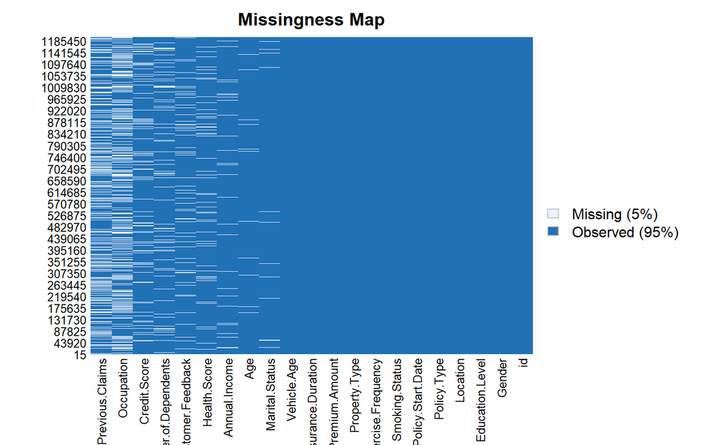

```r
missmap(df)
```

```r
na_resumen <- df |>
  summarise(across(everything(), ~ sum(is.na(.)))) |>
  pivot_longer(everything(), names_to = "Variable", values_to = "N_ausentes") |>
  mutate(Porcentaje = round(N_ausentes / nrow(df) * 100, 2)) |>
  filter(N_ausentes > 0) |>
  arrange(desc(Porcentaje))

na_pct <- function(v) na_resumen$Porcentaje[na_resumen$Variable == v]

knitr::kable(na_resumen,
             caption = "Variables con datos ausentes (pre-imputación)",
             col.names = c("Variable", "N ausentes", "% ausente"))
```

Variables con datos ausentes (pre-imputación)

| Variable | N ausentes | % ausente |
| --- | --- | --- |
| Previous.Claims | 364029 | 30.34 |
| Occupation | 358075 | 29.84 |
| Credit.Score | 137882 | 11.49 |
| Number.of.Dependents | 109672 | 9.14 |
| Customer.Feedback | 77824 | 6.49 |
| Health.Score | 74076 | 6.17 |
| Annual.Income | 44949 | 3.75 |
| Age | 18705 | 1.56 |
| Marital.Status | 18529 | 1.54 |
| Vehicle.Age | 6 | 0.00 |
| Insurance.Duration | 1 | 0.00 |

El `missmap` permite identificar visualmente que la ausencia de información no se distribuye de manera uniforme entre las variables. `Previous.Claims` (30.34 % de ausentes) y `Occupation` (29.84 %) concentran el mayor problema de completitud, seguidas de `Credit.Score` (11.49 %) y `Number.of.Dependents` (9.14 %); en las demás variables la proporción de ausentes es menor. Por esta razón, cualquier interpretación posterior sobre la relación de estas variables con `Premium.Amount` debe hacerse con cautela: la imputación por un valor único aplana artificialmente su varianza y puede debilitar una asociación que en los datos sin imputar podría ser distinta.

## 8 Resumen univariado de predictores

Antes de cruzar cada variable con el target, conviene conocer su propia distribución.

### 8.1 Variables numéricas

```r
df |>
  select(all_of(numeric_vars)) |>
  pivot_longer(everything(), names_to = "Variable", values_to = "v") |>
  group_by(Variable) |>
  summarise(Min = min(v, na.rm = TRUE), Q1 = quantile(v, 0.25, na.rm = TRUE),
            Mediana = median(v, na.rm = TRUE), Media = mean(v, na.rm = TRUE),
            Q3 = quantile(v, 0.75, na.rm = TRUE), Max = max(v, na.rm = TRUE),
            NAs = sum(is.na(v))) |>
  kt(caption = "Resumen de las variables numéricas", digits = 2)
```

Resumen de las variables numéricas

| Variable | Min | Q1 | Mediana | Media | Q3 | Max | NAs |
| --- | --- | --- | --- | --- | --- | --- | --- |
| Age | 18.00 | 30.00 | 41.00 | 41.15 | 53.00 | 64.00 | 18705 |
| Annual.Income | 1.00 | 8001.00 | 23911.00 | 32745.22 | 44634.00 | 149997.00 | 44949 |
| Credit.Score | 300.00 | 468.00 | 595.00 | 592.92 | 721.00 | 849.00 | 137882 |
| Health.Score | 2.01 | 15.92 | 24.58 | 25.61 | 34.53 | 58.98 | 74076 |
| Insurance.Duration | 1.00 | 3.00 | 5.00 | 5.02 | 7.00 | 9.00 | 1 |
| Number.of.Dependents | 0.00 | 1.00 | 2.00 | 2.01 | 3.00 | 4.00 | 109672 |
| Previous.Claims | 0.00 | 0.00 | 1.00 | 1.00 | 2.00 | 9.00 | 364029 |
| Vehicle.Age | 0.00 | 5.00 | 10.00 | 9.57 | 15.00 | 19.00 | 6 |

```r
desc_num <- df |>
  select(all_of(numeric_vars)) |>
  pivot_longer(everything(), names_to = "Variable", values_to = "Valor") |>
  group_by(Variable) |>
  summarise(
    N       = sum(!is.na(Valor)),
    Media   = round(mean(Valor, na.rm = TRUE), 2),
    DE      = round(sd(Valor, na.rm = TRUE), 2),
    Mediana = round(median(Valor, na.rm = TRUE), 2),
    IQR     = round(IQR(Valor, na.rm = TRUE), 2),
    Minimo  = round(min(Valor, na.rm = TRUE), 2),
    Maximo  = round(max(Valor, na.rm = TRUE), 2)
  )

knitr::kable(desc_num,
             caption = "Estadísticos descriptivos — variables numéricas (pre-imputación)",
             align = "lrrrrrrr")
```

Estadísticos descriptivos — variables numéricas (pre-imputación)

| Variable | N | Media | DE | Mediana | IQR | Minimo | Maximo |
| --- | --- | --- | --- | --- | --- | --- | --- |
| Age | 1181295 | 41.15 | 13.54 | 41.00 | 23.00 | 18.00 | 64.00 |
| Annual.Income | 1155051 | 32745.22 | 32179.51 | 23911.00 | 36633.00 | 1.00 | 149997.00 |
| Credit.Score | 1062118 | 592.92 | 149.98 | 595.00 | 253.00 | 300.00 | 849.00 |
| Health.Score | 1125924 | 25.61 | 12.20 | 24.58 | 18.61 | 2.01 | 58.98 |
| Insurance.Duration | 1199999 | 5.02 | 2.59 | 5.00 | 4.00 | 1.00 | 9.00 |
| Number.of.Dependents | 1090328 | 2.01 | 1.42 | 2.00 | 2.00 | 0.00 | 4.00 |
| Previous.Claims | 835971 | 1.00 | 0.98 | 1.00 | 2.00 | 0.00 | 9.00 |
| Vehicle.Age | 1199994 | 9.57 | 5.78 | 10.00 | 10.00 | 0.00 | 19.00 |

La tabla muestra que `Annual.Income` presenta la mayor dispersión absoluta (DE elevada), mientras que `Health.Score` muestra una distribución con media y mediana más próximas, sugiriendo menor asimetría. Variables como `Number.of.Dependents` y `Vehicle.Age` tienen rangos acotados, mientras que `Credit.Score` e `Insurance.Duration` presentan distribuciones de escala moderada.

### 8.2 Variables categóricas

```r
map_dfr(categorical_vars, function(v) {
  tibble(Variable = v, Categoria = df[[v]]) |>
    count(Variable, Categoria) |>
    mutate(Categoria = replace_na(Categoria, "(NA)"),
           Porcentaje = round(100 * n / sum(n), 2))
}) |>
  kt(caption = "Frecuencias de las variables categóricas (incluye ausentes)")
```

Frecuencias de las variables categóricas (incluye ausentes)

| Variable | Categoria | n | Porcentaje |
| --- | --- | --- | --- |
| Gender | Female | 597429 | 49.79 |
| Gender | Male | 602571 | 50.21 |
| Marital.Status | Divorced | 391764 | 32.65 |
| Marital.Status | Married | 394316 | 32.86 |
| Marital.Status | Single | 395391 | 32.95 |
| Marital.Status | (NA) | 18529 | 1.54 |
| Education.Level | Bachelor’s | 303234 | 25.27 |
| Education.Level | High School | 289441 | 24.12 |
| Education.Level | Master’s | 303818 | 25.32 |
| Education.Level | PhD | 303507 | 25.29 |
| Occupation | Employed | 282750 | 23.56 |
| Occupation | Self-Employed | 282645 | 23.55 |
| Occupation | Unemployed | 276530 | 23.04 |
| Occupation | (NA) | 358075 | 29.84 |
| Location | Rural | 400947 | 33.41 |
| Location | Suburban | 401542 | 33.46 |
| Location | Urban | 397511 | 33.13 |
| Policy.Type | Basic | 398554 | 33.21 |
| Policy.Type | Comprehensive | 399600 | 33.30 |
| Policy.Type | Premium | 401846 | 33.49 |
| Customer.Feedback | Average | 377905 | 31.49 |
| Customer.Feedback | Good | 368753 | 30.73 |
| Customer.Feedback | Poor | 375518 | 31.29 |
| Customer.Feedback | (NA) | 77824 | 6.49 |
| Smoking.Status | No | 598127 | 49.84 |
| Smoking.Status | Yes | 601873 | 50.16 |
| Exercise.Frequency | Daily | 294571 | 24.55 |
| Exercise.Frequency | Monthly | 299830 | 24.99 |
| Exercise.Frequency | Rarely | 299420 | 24.95 |
| Exercise.Frequency | Weekly | 306179 | 25.51 |
| Property.Type | Apartment | 399978 | 33.33 |
| Property.Type | Condo | 399673 | 33.31 |
| Property.Type | House | 400349 | 33.36 |

Las tablas de frecuencia revelan que `Gender` y `Smoking.Status` presentan distribuciones relativamente equilibradas entre sus categorías. `Policy.Type` incluye tres opciones (Basic, Comprehensive, Premium), y `Occupation`, con tres categorías, registra el mayor número de ausentes entre las variables categóricas; `Education.Level` y `Exercise.Frequency` son las de más categorías (cuatro).

## 9 Variable objetivo: `Premium.Amount`

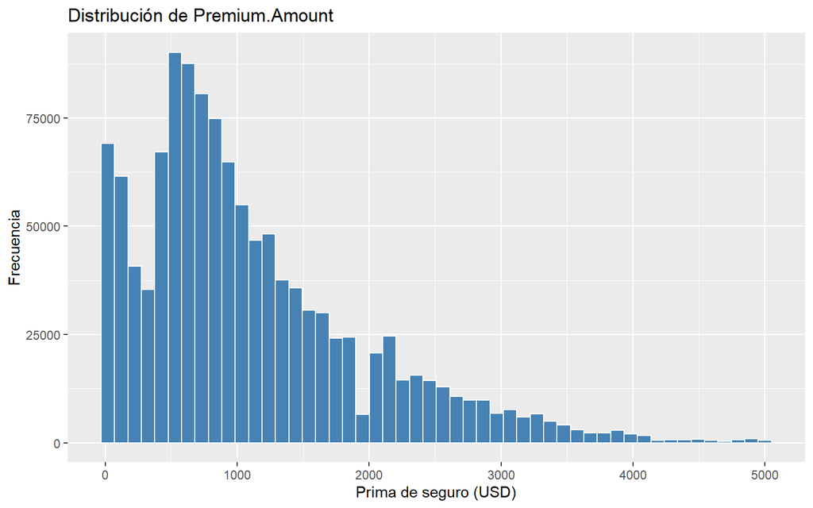

```r
ggplot(df, aes(x = Premium.Amount)) +
    geom_histogram(bins = 50, fill = "steelblue", color = "white") +
    labs(title = "Distribución de Premium.Amount",
         x = "Prima de seguro (USD)", y = "Frecuencia")
```

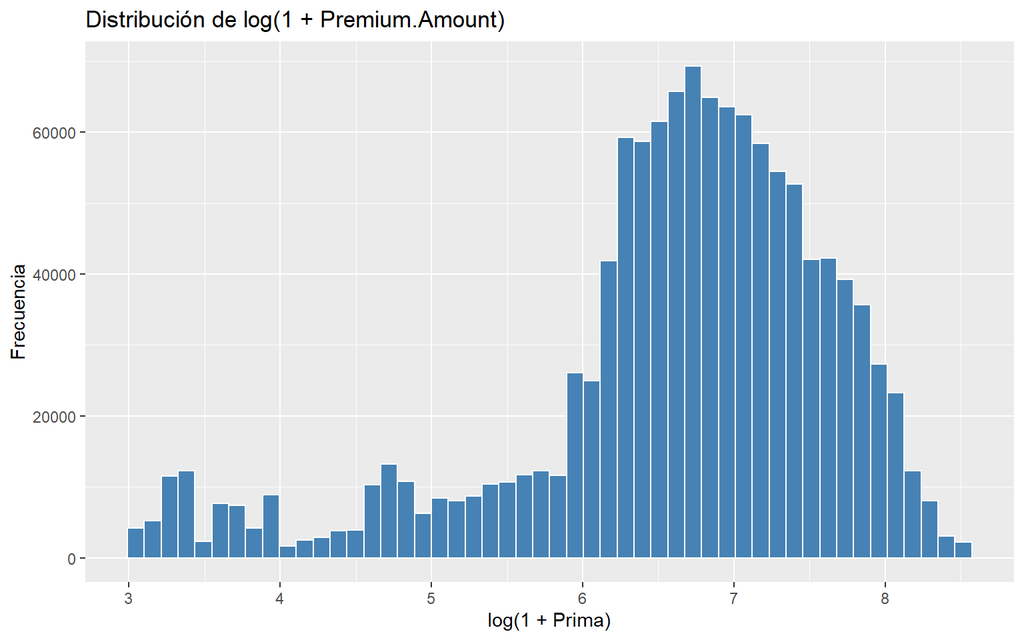

```r
ggplot(df, aes(x = log1p(Premium.Amount))) +
    geom_histogram(bins = 50, fill = "steelblue", color = "white") +
    labs(title = "Distribución de log(1 + Premium.Amount)",
         x = "log(1 + Prima)", y = "Frecuencia")
```

```r
media_premium   <- round(mean(df$Premium.Amount, na.rm = TRUE), 2)
mediana_premium <- round(median(df$Premium.Amount, na.rm = TRUE), 2)
sd_premium      <- round(sd(df$Premium.Amount, na.rm = TRUE), 2)
iqr_premium     <- round(IQR(df$Premium.Amount, na.rm = TRUE), 2)
min_premium     <- round(min(df$Premium.Amount, na.rm = TRUE), 2)
max_premium     <- round(max(df$Premium.Amount, na.rm = TRUE), 2)

# Coeficiente de asimetria (momento estandarizado de orden 3)
asimetria <- function(x) { x <- x[!is.na(x)]; mean((x - mean(x))^3) / sd(x)^3 }
asim_orig <- round(asimetria(df$Premium.Amount), 3)
asim_log  <- round(asimetria(log1p(df$Premium.Amount)), 3)
```

En la escala original, `Premium.Amount` presenta una concentración importante de observaciones en valores bajos y medios, junto con una cola prolongada hacia valores altos. Esto se refleja en una media de 1102.54 USD superior a la mediana de 872 USD, confirmando asimetría positiva. La desviación estándar es 865 USD y el IQR es 995 USD, lo que evidencia una dispersión amplia. Al aplicar `log(1 + Premium.Amount)`, la cola derecha se comprime, pero el coeficiente de asimetría pasa de 1.241 a -1.256: el logaritmo **sobrecorrige** y deja una cola izquierda de magnitud similar. La transformación se mantiene por su coherencia con la métrica RMSLE y su interpretación porcentual, no porque produzca una distribución simétrica; en la sección de regresión, Box-Cox sugiere una potencia intermedia.

## 10 Análisis bivariado

### 10.1 Variables numéricas vs target

```r
# Correlaciones exploratorias (dataset completo) para interpretar cada diagrama
cor_exploratorias <- tibble(
  Variable = numeric_vars,
  r = sapply(numeric_vars, function(v) {
    cor(df[[v]], df$Premium.Amount, use = "complete.obs")
  })
) |>
  mutate(
    r = round(r, 4),
    Direccion = case_when(r > 0 ~ "positiva", r < 0 ~ "negativa", TRUE ~ "nula"),
    Magnitud = case_when(
      abs(r) < 0.10 ~ "insignificante",
      abs(r) < 0.30 ~ "débil",
      abs(r) < 0.50 ~ "moderada",
      TRUE ~ "alta"
    )
  )

# Para agilizar el renderizado de los gráficos se utiliza una muestra reproducible.
# Las pruebas estadísticas posteriores se realizan con el dataset completo.
set.seed(42)
df_plot <- df |>
    slice_sample(n = min(10000, nrow(df)))
```

Para que el documento se ejecute de forma eficiente, los diagramas se construyen sobre una muestra reproducible de 10 000 observaciones; las correlaciones y las medianas citadas en cada interpretación se calculan con el conjunto de datos completo.

```r
for (v in numeric_vars) {
  cat("\n\n#### `", v, "` vs `Premium.Amount`\n\n", sep = "")
  p <- ggplot(df_plot, aes(x = .data[[v]], y = Premium.Amount)) +
    geom_point(alpha = 0.08, color = "steelblue", size = 0.8) +
    labs(title = paste("Premium.Amount vs", v), x = v, y = "Prima (USD)")
  print(p)

  x      <- df[[v]]
  fila   <- cor_exploratorias[cor_exploratorias$Variable == v, ]
  q      <- quantile(x, c(0.25, 0.75), na.rm = TRUE)
  med_lo <- median(df$Premium.Amount[!is.na(x) & x <= q[1]])
  med_hi <- median(df$Premium.Amount[!is.na(x) & x >= q[2]])
  discreta <- n_distinct(x, na.rm = TRUE) <= 20
  forma <- if (discreta) {
    paste0("Al ser una variable discreta (", n_distinct(x, na.rm = TRUE),
           " valores distintos), los puntos se agrupan en bandas verticales; ",
           "dentro de cada banda la prima recorre prácticamente todo su rango.")
  } else {
    "Los puntos forman una nube sin una pendiente visible; la prima se dispersa ampliamente para cualquier valor del predictor."
  }
  cat("\n\n", forma, " El rango observado va de ",
      format(round(min(x, na.rm = TRUE), 2), big.mark = ","), " a ",
      format(round(max(x, na.rm = TRUE), 2), big.mark = ","),
      ". La correlación de Pearson es r = ", fila$r, ", de dirección ", fila$Direccion,
      " y magnitud ", fila$Magnitud, ". La mediana de la prima es ",
      round(med_lo, 2), " USD cuando `", v, "` está en su cuartil inferior y ",
      round(med_hi, 2), " USD cuando está en su cuartil superior",
      ifelse(abs(med_hi - med_lo) / median(df$Premium.Amount) < 0.05,
             ", una diferencia mínima que confirma la ausencia de tendencia visual.",
             paste0(", una diferencia de ", round(med_hi - med_lo, 2),
                    " USD que, frente a la dispersión de la nube, no constituye una tendencia lineal fuerte.")),
      "\n\n", sep = "")
}
```

#### 10.1.1 `Age` vs `Premium.Amount`

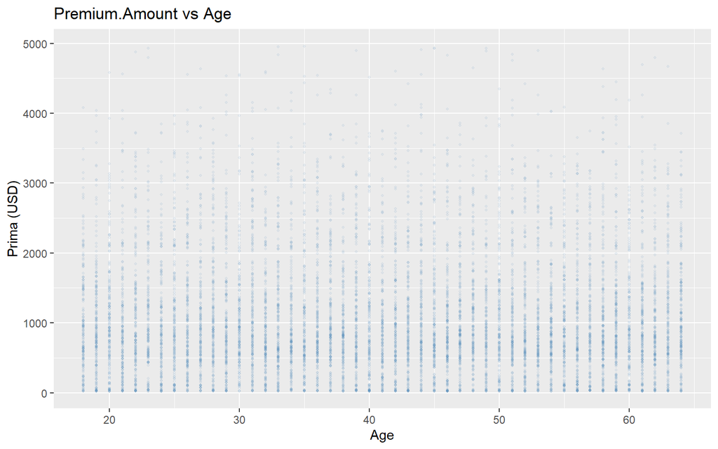

Los puntos forman una nube sin una pendiente visible; la prima se dispersa ampliamente para cualquier valor del predictor. El rango observado va de 18 a 64. La correlación de Pearson es r = -0.0024, de dirección negativa y magnitud insignificante. La mediana de la prima es 874 USD cuando `Age` está en su cuartil inferior y 871 USD cuando está en su cuartil superior, una diferencia mínima que confirma la ausencia de tendencia visual.

#### 10.1.2 `Annual.Income` vs `Premium.Amount`

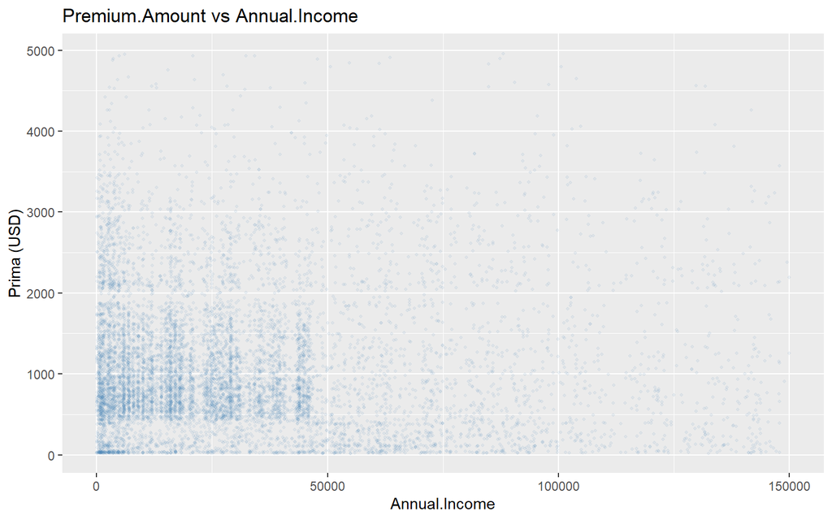

Los puntos forman una nube sin una pendiente visible; la prima se dispersa ampliamente para cualquier valor del predictor. El rango observado va de 1 a 149,997. La correlación de Pearson es r = -0.0124, de dirección negativa y magnitud insignificante. La mediana de la prima es 923 USD cuando `Annual.Income` está en su cuartil inferior y 757 USD cuando está en su cuartil superior, una diferencia de -166 USD que, frente a la dispersión de la nube, no constituye una tendencia lineal fuerte.

#### 10.1.3 `Health.Score` vs `Premium.Amount`

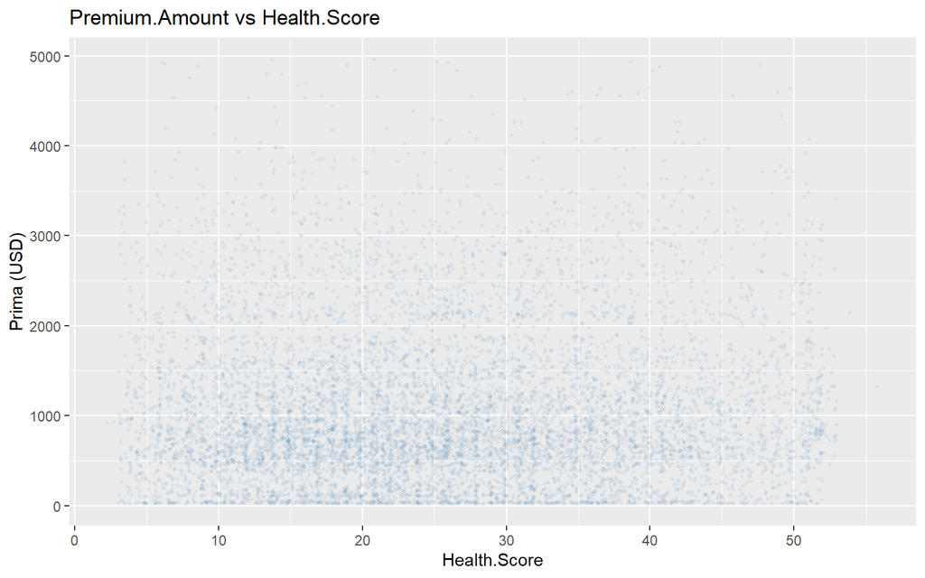

Los puntos forman una nube sin una pendiente visible; la prima se dispersa ampliamente para cualquier valor del predictor. El rango observado va de 2.01 a 58.98. La correlación de Pearson es r = 0.0147, de dirección positiva y magnitud insignificante. La mediana de la prima es 867 USD cuando `Health.Score` está en su cuartil inferior y 897 USD cuando está en su cuartil superior, una diferencia mínima que confirma la ausencia de tendencia visual.

#### 10.1.4 `Number.of.Dependents` vs `Premium.Amount`

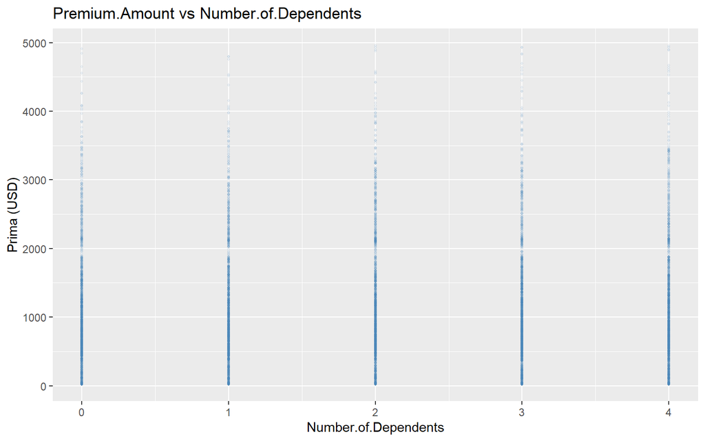

Al ser una variable discreta (5 valores distintos), los puntos se agrupan en bandas verticales; dentro de cada banda la prima recorre prácticamente todo su rango. El rango observado va de 0 a 4. La correlación de Pearson es r = -0.001, de dirección negativa y magnitud insignificante. La mediana de la prima es 871 USD cuando `Number.of.Dependents` está en su cuartil inferior y 870 USD cuando está en su cuartil superior, una diferencia mínima que confirma la ausencia de tendencia visual.

#### 10.1.5 `Previous.Claims` vs `Premium.Amount`

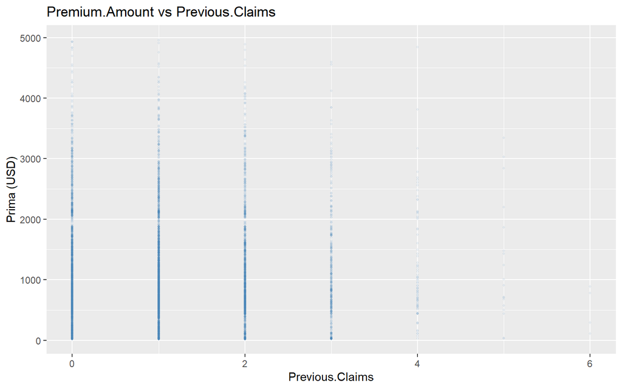

Al ser una variable discreta (10 valores distintos), los puntos se agrupan en bandas verticales; dentro de cada banda la prima recorre prácticamente todo su rango. El rango observado va de 0 a 9. La correlación de Pearson es r = 0.0469, de dirección positiva y magnitud insignificante. La mediana de la prima es 852 USD cuando `Previous.Claims` está en su cuartil inferior y 942 USD cuando está en su cuartil superior, una diferencia de 90 USD que, frente a la dispersión de la nube, no constituye una tendencia lineal fuerte.

#### 10.1.6 `Vehicle.Age` vs `Premium.Amount`

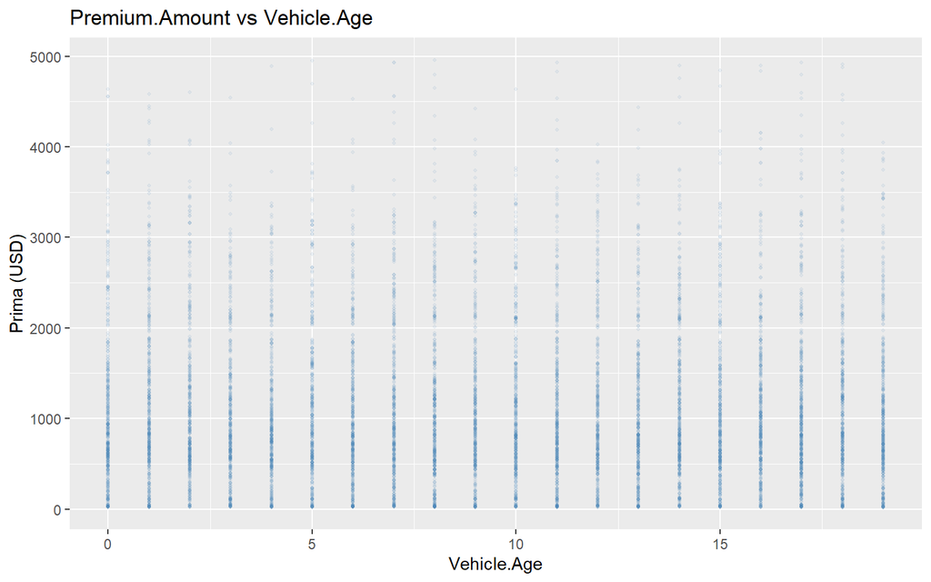

Al ser una variable discreta (20 valores distintos), los puntos se agrupan en bandas verticales; dentro de cada banda la prima recorre prácticamente todo su rango. El rango observado va de 0 a 19. La correlación de Pearson es r = 4e-04, de dirección positiva y magnitud insignificante. La mediana de la prima es 872 USD cuando `Vehicle.Age` está en su cuartil inferior y 873 USD cuando está en su cuartil superior, una diferencia mínima que confirma la ausencia de tendencia visual.

#### 10.1.7 `Credit.Score` vs `Premium.Amount`

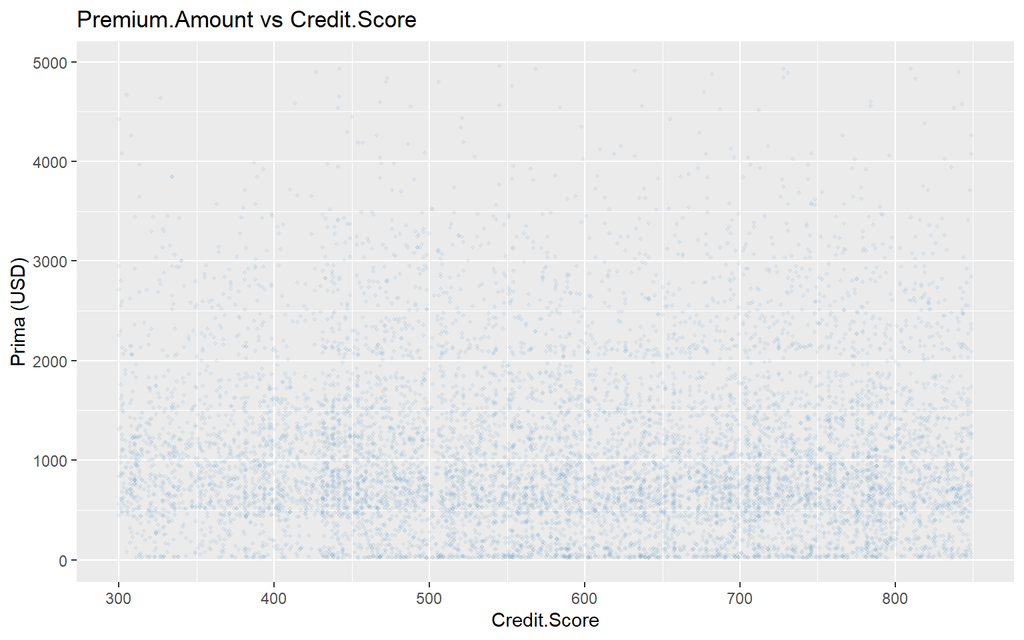

Los puntos forman una nube sin una pendiente visible; la prima se dispersa ampliamente para cualquier valor del predictor. El rango observado va de 300 a 849. La correlación de Pearson es r = -0.026, de dirección negativa y magnitud insignificante. La mediana de la prima es 938 USD cuando `Credit.Score` está en su cuartil inferior y 843 USD cuando está en su cuartil superior, una diferencia de -95 USD que, frente a la dispersión de la nube, no constituye una tendencia lineal fuerte.

#### 10.1.8 `Insurance.Duration` vs `Premium.Amount`

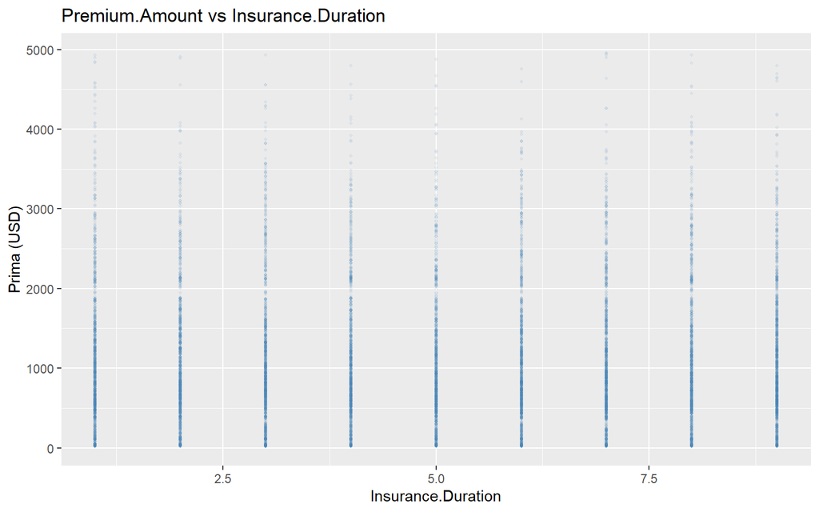

Al ser una variable discreta (9 valores distintos), los puntos se agrupan en bandas verticales; dentro de cada banda la prima recorre prácticamente todo su rango. El rango observado va de 1 a 9. La correlación de Pearson es r = 0, de dirección nula y magnitud insignificante. La mediana de la prima es 871 USD cuando `Insurance.Duration` está en su cuartil inferior y 872 USD cuando está en su cuartil superior, una diferencia mínima que confirma la ausencia de tendencia visual.

```r
knitr::kable(
  cor_exploratorias,
  caption = "Resumen de la lectura de los diagramas de dispersión",
  col.names = c("Variable", "r", "Dirección", "Magnitud")
)
```

Resumen de la lectura de los diagramas de dispersión

| Variable | r | Dirección | Magnitud |
| --- | --- | --- | --- |
| Age | -0.0024 | negativa | insignificante |
| Annual.Income | -0.0124 | negativa | insignificante |
| Health.Score | 0.0147 | positiva | insignificante |
| Number.of.Dependents | -0.0010 | negativa | insignificante |
| Previous.Claims | 0.0469 | positiva | insignificante |
| Vehicle.Age | 0.0004 | positiva | insignificante |
| Credit.Score | -0.0260 | negativa | insignificante |
| Insurance.Duration | 0.0000 | nula | insignificante |

Las nubes de puntos muestran una dispersión vertical amplia para todos los predictores, por lo que ninguna variable numérica presenta visualmente una relación lineal fuerte con `Premium.Amount`. La tabla anterior permite interpretar cada gráfico de forma individual: el signo de `r` indica la dirección de la asociación y su valor absoluto resume la intensidad lineal observada; coeficientes cercanos a cero son coherentes con nubes de puntos sin una tendencia visual clara. Estas correlaciones son descriptivas; de acuerdo con la tabla anterior, `Previous.Claims` y `Credit.Score` presentan los coeficientes de mayor magnitud entre las ocho numéricas, por lo que son las dos variables que se someten posteriormente a comprobación formal de supuestos e inferencia con Spearman.

### 10.2 Correlación entre variables numéricas (chequeo de multicolinealidad)

```r
cor_matrix <- df |>
    select(all_of(numeric_vars), Premium.Amount) |>
    cor(use = "pairwise.complete.obs")
kt(round(cor_matrix, 3), caption = "Matriz de correlaciones de Pearson", digits = 3)
```

Matriz de correlaciones de Pearson

|  | Age | Annual.Income | Health.Score | Number.of.Dependents | Previous.Claims | Vehicle.Age | Credit.Score | Insurance.Duration | Premium.Amount |
| --- | --- | --- | --- | --- | --- | --- | --- | --- | --- |
| Age | 1.000 | 0.000 | 0.001 | 0.001 | 0.002 | -0.002 | 0.003 | 0.000 | -0.002 |
| Annual.Income | 0.000 | 1.000 | 0.026 | 0.002 | 0.043 | 0.000 | -0.201 | 0.000 | -0.012 |
| Health.Score | 0.001 | 0.026 | 1.000 | 0.005 | 0.002 | 0.000 | 0.012 | 0.002 | 0.015 |
| Number.of.Dependents | 0.001 | 0.002 | 0.005 | 1.000 | -0.004 | 0.001 | -0.002 | 0.000 | -0.001 |
| Previous.Claims | 0.002 | 0.043 | 0.002 | -0.004 | 1.000 | -0.001 | 0.037 | 0.003 | 0.047 |
| Vehicle.Age | -0.002 | 0.000 | 0.000 | 0.001 | -0.001 | 1.000 | 0.001 | 0.003 | 0.000 |
| Credit.Score | 0.003 | -0.201 | 0.012 | -0.002 | 0.037 | 0.001 | 1.000 | 0.000 | -0.026 |
| Insurance.Duration | 0.000 | 0.000 | 0.002 | 0.000 | 0.003 | 0.003 | 0.000 | 1.000 | 0.000 |
| Premium.Amount | -0.002 | -0.012 | 0.015 | -0.001 | 0.047 | 0.000 | -0.026 | 0.000 | 1.000 |

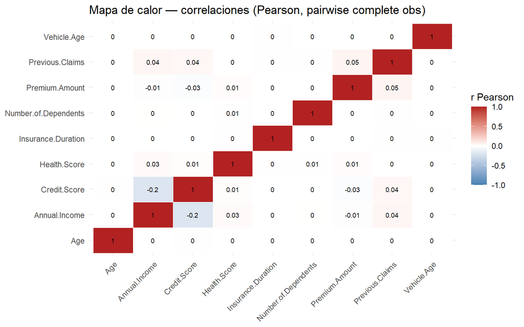

```r
cor_long <- cor_matrix |>
  as.data.frame() |>
  rownames_to_column("var1") |>
  pivot_longer(-var1, names_to = "var2", values_to = "r")

ggplot(cor_long, aes(x = var1, y = var2, fill = r)) +
  geom_tile(color = "white") +
  geom_text(aes(label = round(r, 2)), size = 2.5, color = "black") +
  scale_fill_gradient2(low = "steelblue", mid = "white", high = "firebrick",
                       midpoint = 0, limits = c(-1, 1),
                       name = "r Pearson") +
  theme_minimal() +
  theme(axis.text.x = element_text(angle = 45, hjust = 1),
        axis.title  = element_blank()) +
  labs(title = "Mapa de calor — correlaciones (Pearson, pairwise complete obs)")
```

Los colores cercanos al centro de la escala y los coeficientes próximos a cero indican asociaciones lineales débiles entre la mayoría de pares de variables. En particular, las correlaciones de los predictores numéricos con `Premium.Amount` son pequeñas, por lo que no se observa un predictor continuo que domine linealmente al target. Tampoco se aprecia un patrón de correlaciones extremadamente altas entre predictores que sugiera colinealidad lineal severa. Esta lectura es exploratoria; las correlaciones inferenciales seleccionadas se evalúan posteriormente con sus supuestos.

### 10.3 Variables categóricas vs target

```r
for (v in categorical_vars) {
  cat("\n\n#### `Premium.Amount` por `", v, "`\n\n", sep = "")
  p <- ggplot(df, aes(x = .data[[v]], y = Premium.Amount)) +
    geom_boxplot(fill = "#A7C7E7", alpha = 0.7, outlier.alpha = 0.1) +
    labs(title = paste("Premium.Amount por", v), x = v, y = "Prima (USD)") +
    theme(axis.text.x = element_text(angle = 45, hjust = 1))
  print(p)

  res <- df |>
    filter(!is.na(.data[[v]])) |>
    group_by(Categoria = .data[[v]]) |>
    summarise(Mediana = median(Premium.Amount), IQR = IQR(Premium.Amount), .groups = "drop")
  dif <- max(res$Mediana) - min(res$Mediana)
  txt_med <- if (dif == 0) {
    paste0("Todas las categorías tienen la misma mediana (", round(max(res$Mediana), 2),
           " USD), con")
  } else {
    paste0("La mediana más alta corresponde a ",
           as.character(res$Categoria[which.max(res$Mediana)]), " (", round(max(res$Mediana), 2),
           " USD) y la más baja a ", as.character(res$Categoria[which.min(res$Mediana)]), " (",
           round(min(res$Mediana), 2), " USD), una diferencia de ", round(dif, 2), " USD frente a")
  }
  cat("\n\nLa variable tiene ", nrow(res), " categorías. ", txt_med,
      " un IQR por categoría de entre ", round(min(res$IQR), 2), " y ",
      round(max(res$IQR), 2), " USD. ",
      ifelse(dif < 0.1 * min(res$IQR),
             "Las cajas se superponen casi por completo, por lo que visualmente la prima no cambia entre categorías.",
             "Las cajas se superponen ampliamente; la separación de medianas es pequeña frente a la dispersión dentro de cada grupo."),
      "\n\n", sep = "")
}
```

#### 10.3.1 `Premium.Amount` por `Gender`

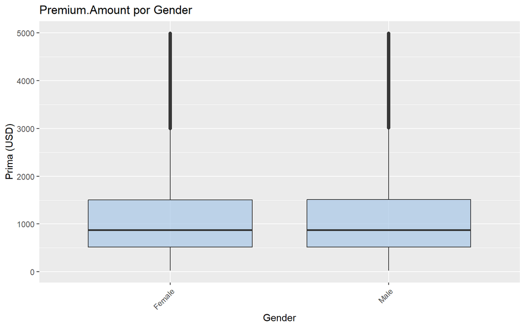

La variable tiene 2 categorías. Todas las categorías tienen la misma mediana (872 USD), con un IQR por categoría de entre 993 y 998 USD. Las cajas se superponen casi por completo, por lo que visualmente la prima no cambia entre categorías.

#### 10.3.2 `Premium.Amount` por `Marital.Status`

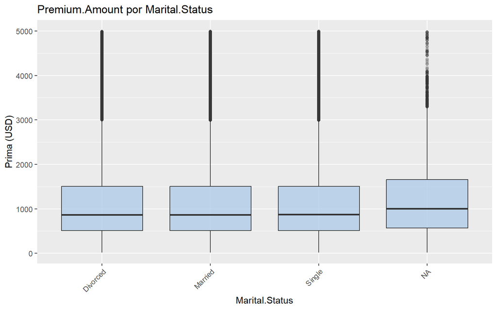

La variable tiene 3 categorías. La mediana más alta corresponde a Single (872 USD) y la más baja a Divorced (870 USD), una diferencia de 2 USD frente a un IQR por categoría de entre 991 y 994 USD. Las cajas se superponen casi por completo, por lo que visualmente la prima no cambia entre categorías.

#### 10.3.3 `Premium.Amount` por `Education.Level`

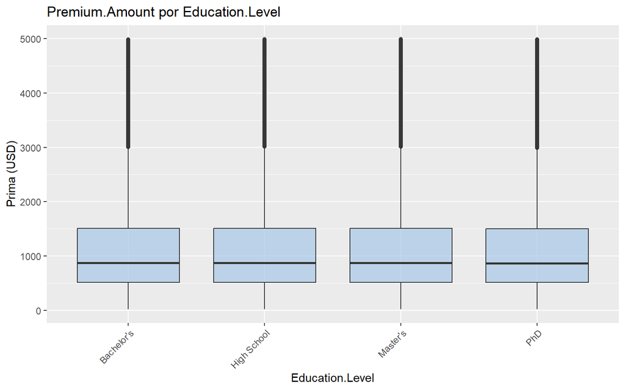

La variable tiene 4 categorías. La mediana más alta corresponde a High School (876 USD) y la más baja a PhD (869 USD), una diferencia de 7 USD frente a un IQR por categoría de entre 988 y 999 USD. Las cajas se superponen casi por completo, por lo que visualmente la prima no cambia entre categorías.

#### 10.3.4 `Premium.Amount` por `Occupation`

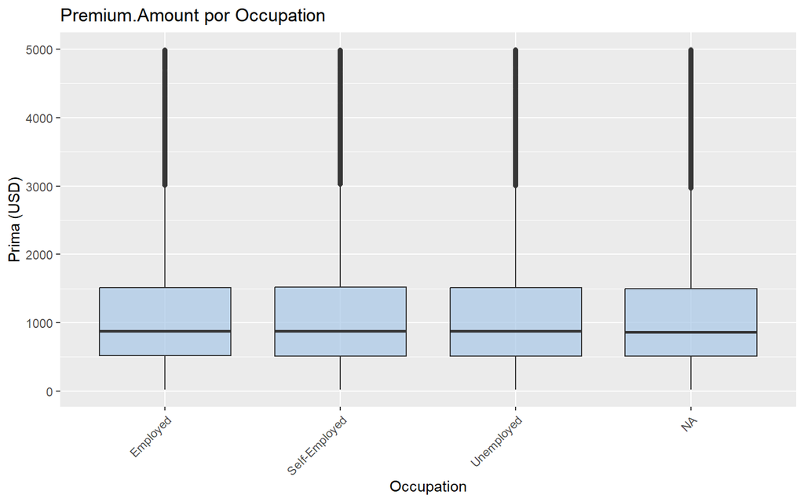

La variable tiene 3 categorías. La mediana más alta corresponde a Employed (881 USD) y la más baja a Self-Employed (874 USD), una diferencia de 7 USD frente a un IQR por categoría de entre 997 y 1005 USD. Las cajas se superponen casi por completo, por lo que visualmente la prima no cambia entre categorías.

#### 10.3.5 `Premium.Amount` por `Location`

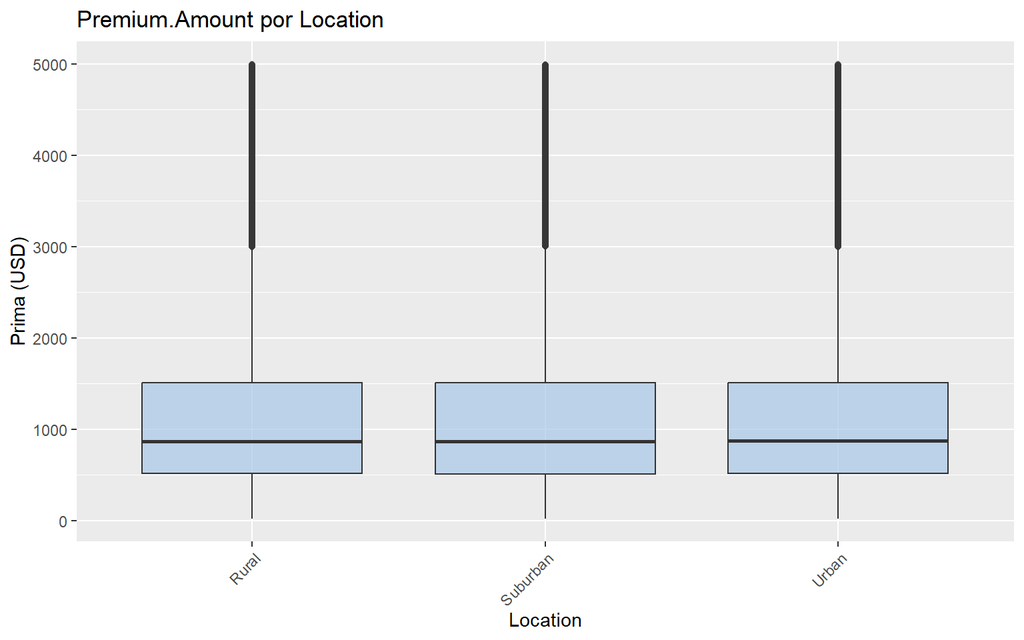

La variable tiene 3 categorías. La mediana más alta corresponde a Urban (874 USD) y la más baja a Rural (871 USD), una diferencia de 3 USD frente a un IQR por categoría de entre 994 y 996 USD. Las cajas se superponen casi por completo, por lo que visualmente la prima no cambia entre categorías.

#### 10.3.6 `Premium.Amount` por `Policy.Type`

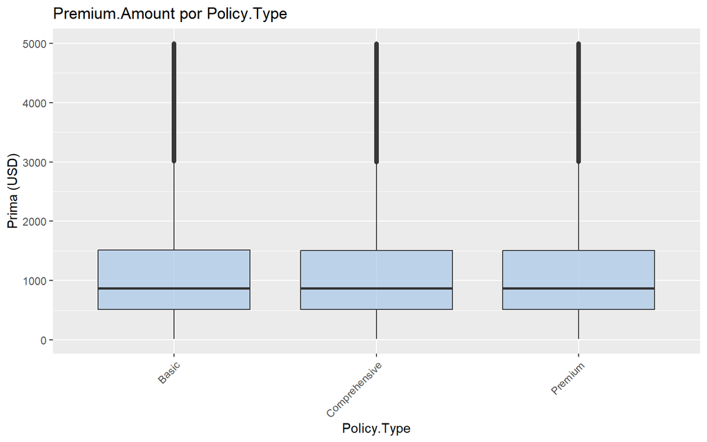

La variable tiene 3 categorías. La mediana más alta corresponde a Basic (874 USD) y la más baja a Premium (870 USD), una diferencia de 4 USD frente a un IQR por categoría de entre 993 y 999 USD. Las cajas se superponen casi por completo, por lo que visualmente la prima no cambia entre categorías.

#### 10.3.7 `Premium.Amount` por `Customer.Feedback`

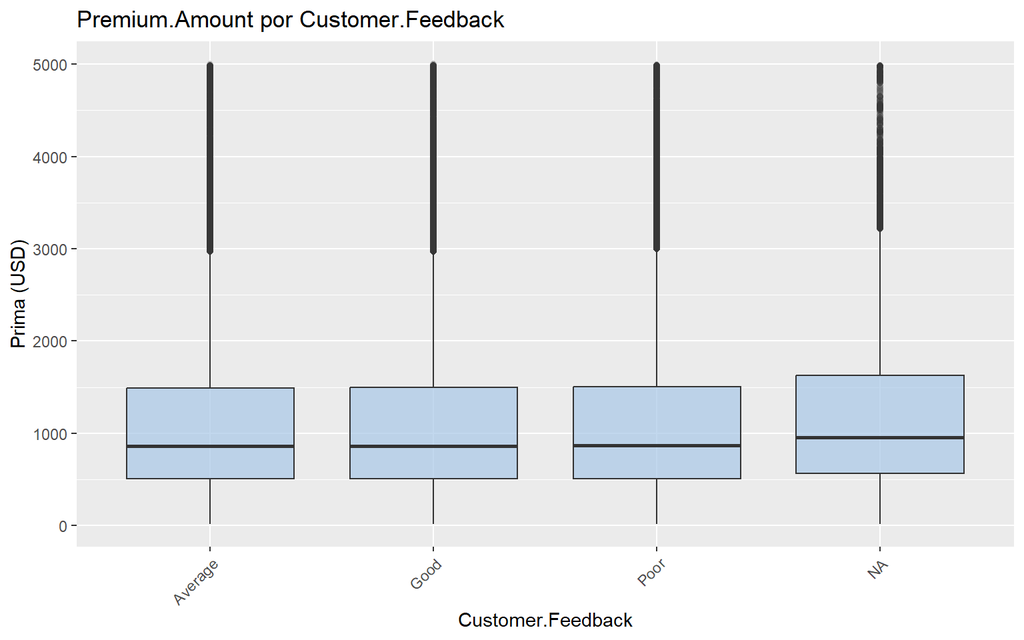

La variable tiene 3 categorías. La mediana más alta corresponde a Poor (868 USD) y la más baja a Average (861 USD), una diferencia de 7 USD frente a un IQR por categoría de entre 985 y 994 USD. Las cajas se superponen casi por completo, por lo que visualmente la prima no cambia entre categorías.

#### 10.3.8 `Premium.Amount` por `Smoking.Status`

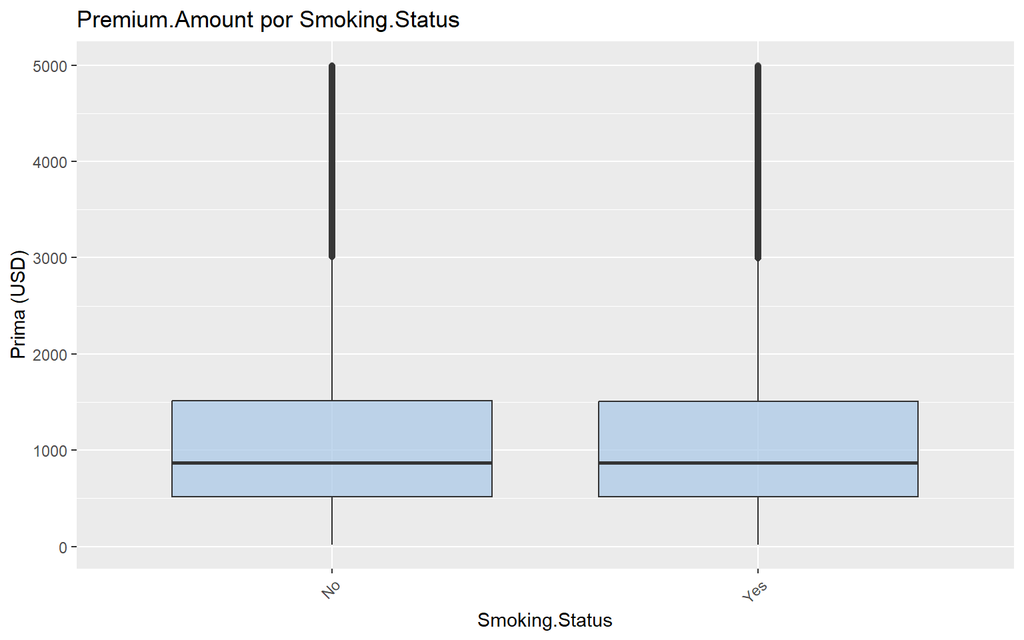

La variable tiene 2 categorías. Todas las categorías tienen la misma mediana (872 USD), con un IQR por categoría de entre 992 y 999 USD. Las cajas se superponen casi por completo, por lo que visualmente la prima no cambia entre categorías.

#### 10.3.9 `Premium.Amount` por `Exercise.Frequency`

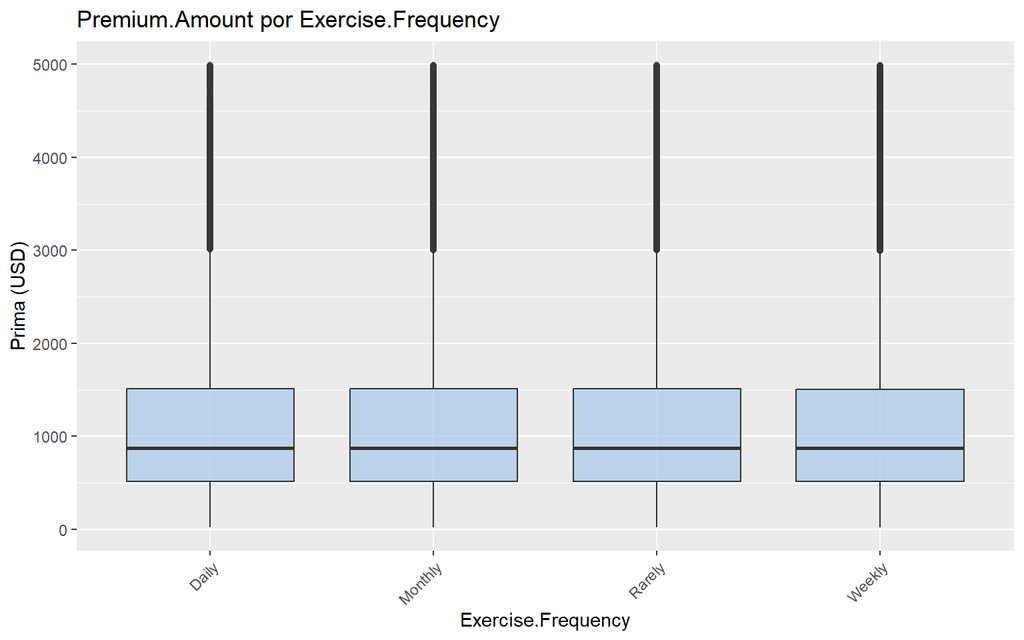

La variable tiene 4 categorías. La mediana más alta corresponde a Daily (874 USD) y la más baja a Monthly (871 USD), una diferencia de 3 USD frente a un IQR por categoría de entre 991 y 998 USD. Las cajas se superponen casi por completo, por lo que visualmente la prima no cambia entre categorías.

#### 10.3.10 `Premium.Amount` por `Property.Type`

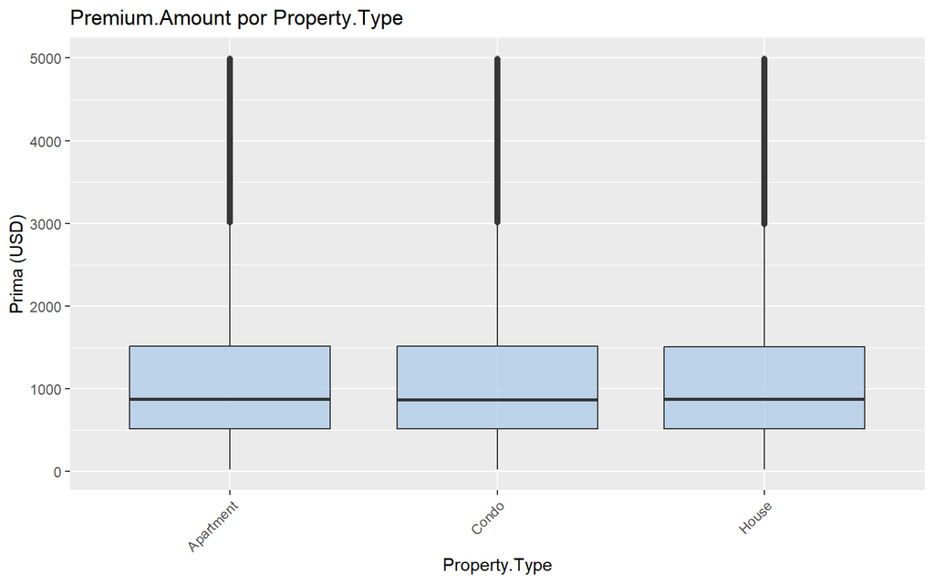

La variable tiene 3 categorías. La mediana más alta corresponde a House (873 USD) y la más baja a Condo (871 USD), una diferencia de 2 USD frente a un IQR por categoría de entre 991 y 999 USD. Las cajas se superponen casi por completo, por lo que visualmente la prima no cambia entre categorías.

```r
resumen_cat <- map_dfr(categorical_vars, function(v) {
  tmp <- df |>
    filter(!is.na(.data[[v]])) |>
    group_by(Categoria = .data[[v]]) |>
    summarise(
      Mediana = median(Premium.Amount, na.rm = TRUE),
      Media = mean(Premium.Amount, na.rm = TRUE),
      .groups = "drop"
    )

  tibble(
    Variable = v,
    Mediana_min = round(min(tmp$Mediana), 2),
    Mediana_max = round(max(tmp$Mediana), 2),
    Diferencia_mediana = round(max(tmp$Mediana) - min(tmp$Mediana), 2)
  )
})

knitr::kable(
  resumen_cat,
  caption = "Resumen para la interpretación de los boxplots categóricos",
  col.names = c("Variable", "Mediana mínima", "Mediana máxima", "Diferencia entre medianas")
)
```

Resumen para la interpretación de los boxplots categóricos

| Variable | Mediana mínima | Mediana máxima | Diferencia entre medianas |
| --- | --- | --- | --- |
| Gender | 872 | 872 | 0 |
| Marital.Status | 870 | 872 | 2 |
| Education.Level | 869 | 876 | 7 |
| Occupation | 874 | 881 | 7 |
| Location | 871 | 874 | 3 |
| Policy.Type | 870 | 874 | 4 |
| Customer.Feedback | 861 | 868 | 7 |
| Smoking.Status | 872 | 872 | 0 |
| Exercise.Frequency | 871 | 874 | 3 |
| Property.Type | 871 | 873 | 2 |

En cada gráfico se comparan la mediana, el rango intercuartílico y la dispersión de `Premium.Amount` entre las categorías de una misma variable. La tabla anterior cuantifica la separación visual entre medianas para **cada** boxplot. Una diferencia visual pequeña y cajas ampliamente superpuestas sugiere que las distribuciones son similares; una mayor separación de medianas señala una posible diferencia que debe comprobarse formalmente. Estos gráficos no se utilizan por sí solos para declarar significancia estadística. `Smoking.Status` y `Policy.Type` se analizan formalmente más adelante mediante Mann-Whitney y Kruskal-Wallis, respectivamente.

### 10.4 `Policy.Start.Date`

Se convierte a fecha real y se extraen componentes temporales que podrían capturar estacionalidad.

```r
df <- df |>
    mutate(
        Policy.Start.Date  = as.POSIXct(Policy.Start.Date),
        Policy.Start.Year  = year(Policy.Start.Date),
        Policy.Start.Month = month(Policy.Start.Date),
        Policy.Start.Wday  = wday(Policy.Start.Date, label = TRUE)
    )
```

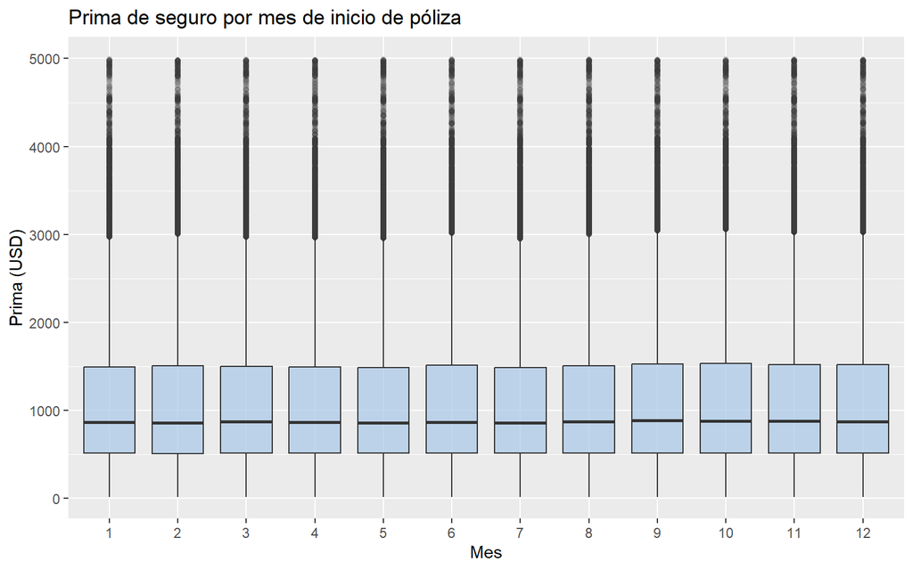

```r
ggplot(df, aes(x = factor(Policy.Start.Month), y = Premium.Amount)) +
  geom_boxplot(fill = "#A7C7E7", alpha = 0.7, outlier.alpha = 0.05) +
  labs(title = "Prima de seguro por mes de inicio de póliza",
       x = "Mes", y = "Prima (USD)")
```

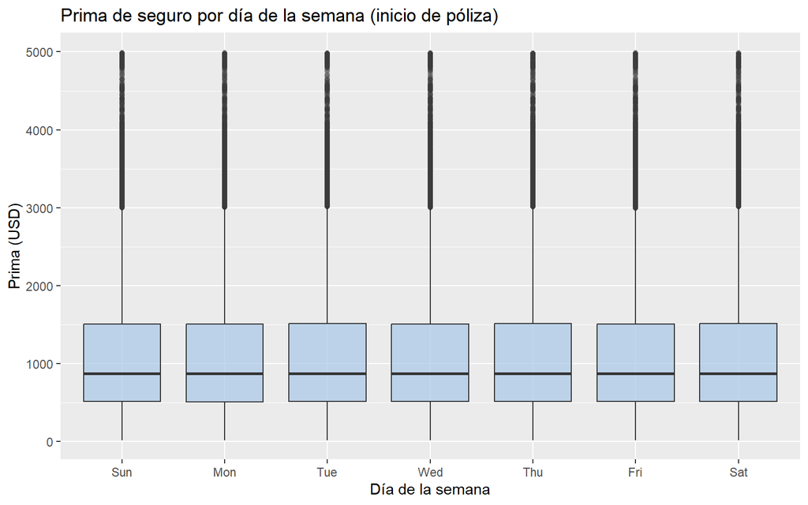

```r
ggplot(df, aes(x = Policy.Start.Wday, y = Premium.Amount)) +
  geom_boxplot(fill = "#A7C7E7", alpha = 0.7, outlier.alpha = 0.05) +
  labs(title = "Prima de seguro por día de la semana (inicio de póliza)",
       x = "Día de la semana", y = "Prima (USD)")
```

```r
resumen_mes <- df |>
  group_by(Policy.Start.Month) |>
  summarise(Mediana = median(Premium.Amount), .groups = "drop")

resumen_dia <- df |>
  group_by(Policy.Start.Wday) |>
  summarise(Mediana = median(Premium.Amount), .groups = "drop")

rango_mediana_mes <- round(max(resumen_mes$Mediana) - min(resumen_mes$Mediana), 2)
rango_mediana_dia <- round(max(resumen_dia$Mediana) - min(resumen_dia$Mediana), 2)
```

En el boxplot por mes, las cajas permiten comparar si existe un desplazamiento sistemático de la prima a lo largo del año. La diferencia entre la mayor y la menor mediana mensual es de 24 USD. En el gráfico por día de la semana, la diferencia entre medianas extremas es de 5 USD. Cuando las cajas se superponen ampliamente y estas diferencias son pequeñas frente a la dispersión total de `Premium.Amount`, la evidencia visual de estacionalidad es limitada. Estos gráficos son exploratorios y no equivalen a una prueba formal de diferencias.

## 11 Imputación de ausentes

Numéricas: mediana de la columna. Categóricas: moda. Se reitera la advertencia sobre `Previous.Claims` y `Credit.Score` por su alta proporción de ausentes.

```r
moda <- function(x) {
    ux <- na.omit(unique(x))
    ux[which.max(tabulate(match(x, ux)))]
}

df <- df |>
    mutate(across(all_of(numeric_vars), ~ replace_na(., median(., na.rm = TRUE)))) |>
    mutate(across(all_of(categorical_vars), ~ replace_na(., moda(.))))

# verificacion: deberian quedar todas en 0
kt(tibble(Variables = ncol(df), `Total de NA restantes` = sum(is.na(df))),
   caption = "Verificación posterior a la imputación")
```

Verificación posterior a la imputación

| Variables | Total de NA restantes |
| --- | --- |
| 24 | 0 |

Tras la imputación, el dataset queda libre de valores ausentes y disponible para los análisis siguientes.

## 12 Ingeniería de características

Se crean nuevas variables derivadas de las existentes cuando la transformación aporta valor analítico: mejora la simetría de la distribución, habilita pruebas que requieren variables categóricas o extrae información latente de variables continuas.

```r
df <- df |>
  mutate(
    # Transformacion logaritmica del target: corrige asimetria positiva
    log_premium = log1p(Premium.Amount),

    # Grupos de edad: facilita analisis de asociacion categorica
    Age_Group = cut(
      Age,
      breaks = c(0, 30, 50, Inf),
      labels = c("Joven (<30)", "Adulto (30-49)", "Mayor (≥50)"),
      right  = FALSE
    ),

    # Cuartiles de ingreso anual
    Income_Q = cut(
      Annual.Income,
      breaks = quantile(Annual.Income, probs = c(0, 0.25, 0.50, 0.75, 1)),
      labels = c("Q1", "Q2", "Q3", "Q4"),
      include.lowest = TRUE
    )
  )
```

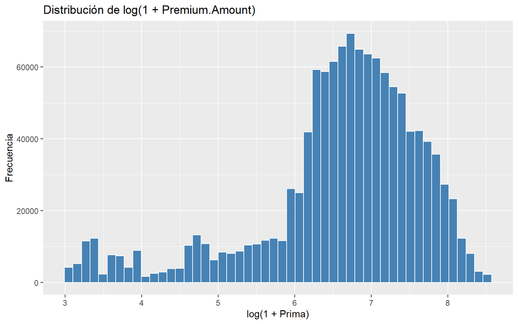

```r
# Verificar la transformacion logaritmica
ggplot(df, aes(x = log_premium)) +
  geom_histogram(bins = 50, fill = "steelblue", color = "white") +
  labs(title = "Distribución de log(1 + Premium.Amount)",
       x = "log(1 + Prima)", y = "Frecuencia")
```

```r
# Distribucion de grupos de edad
knitr::kable(table(df$Age_Group),
             caption = "Frecuencia por grupo de edad",
             col.names = c("Grupo de edad", "n"))
```

Frecuencia por grupo de edad

| Grupo de edad | n |
| --- | --- |
| Joven (<30) | 294761 |
| Adulto (30-49) | 524615 |
| Mayor (≥50) | 380624 |

```r
# Distribucion de cuartiles de ingreso
knitr::kable(table(df$Income_Q),
             caption = "Frecuencia por cuartil de ingreso",
             col.names = c("Cuartil de ingreso", "n"))
```

Frecuencia por cuartil de ingreso

| Cuartil de ingreso | n |
| --- | --- |
| Q1 | 300008 |
| Q2 | 322471 |
| Q3 | 277575 |
| Q4 | 299946 |

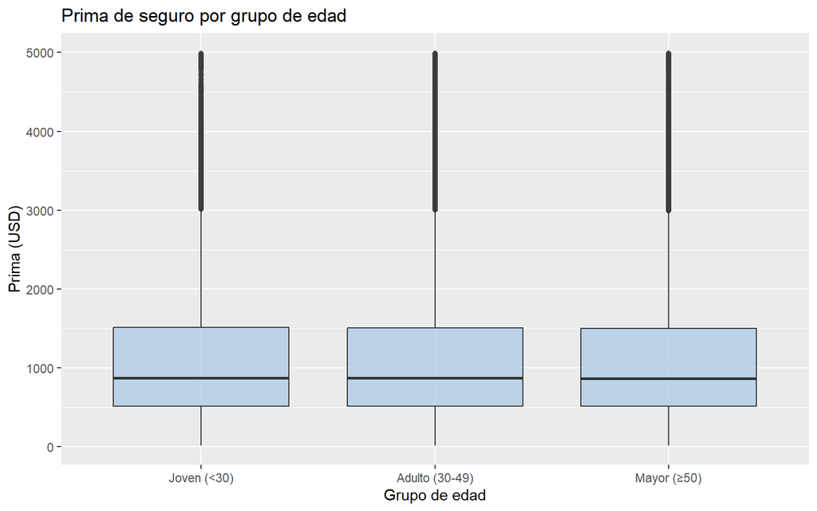

```r
# Prima segun grupo de edad
ggplot(df, aes(x = Age_Group, y = Premium.Amount)) +
  geom_boxplot(fill = "#A7C7E7", alpha = 0.7, outlier.alpha = 0.05) +
  labs(title = "Prima de seguro por grupo de edad",
       x = "Grupo de edad", y = "Prima (USD)")
```

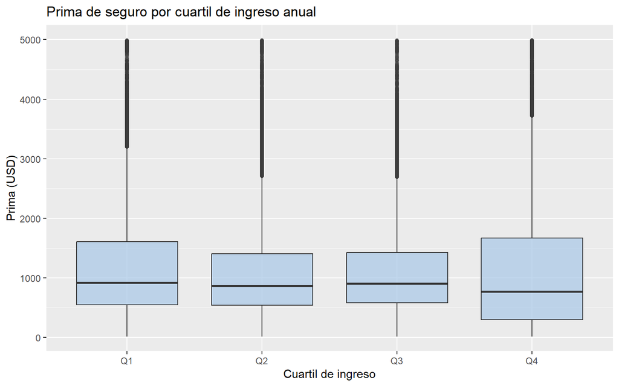

```r
# Prima segun cuartil de ingreso
ggplot(df, aes(x = Income_Q, y = Premium.Amount)) +
  geom_boxplot(fill = "#A7C7E7", alpha = 0.7, outlier.alpha = 0.05) +
  labs(title = "Prima de seguro por cuartil de ingreso anual",
       x = "Cuartil de ingreso", y = "Prima (USD)")
```

```r
resumen_age_group <- df |>
  group_by(Age_Group) |>
  summarise(Mediana = round(median(Premium.Amount), 2),
            IQR = round(IQR(Premium.Amount), 2), .groups = "drop")

resumen_income_q <- df |>
  group_by(Income_Q) |>
  summarise(Mediana = round(median(Premium.Amount), 2),
            IQR = round(IQR(Premium.Amount), 2), .groups = "drop")

knitr::kable(resumen_age_group,
             caption = "Mediana e IQR de la prima por grupo de edad")
```

Mediana e IQR de la prima por grupo de edad

| Age_Group | Mediana | IQR |
| --- | --- | --- |
| Joven (<30) | 874 | 999 |
| Adulto (30-49) | 872 | 995 |
| Mayor (≥50) | 870 | 991 |

```r
knitr::kable(resumen_income_q,
             caption = "Mediana e IQR de la prima por cuartil de ingreso")
```

Mediana e IQR de la prima por cuartil de ingreso

| Income_Q | Mediana | IQR |
| --- | --- | --- |
| Q1 | 919 | 1058 |
| Q2 | 866 | 868 |
| Q3 | 906 | 845 |
| Q4 | 772 | 1369 |

El histograma de `log_premium` confirma que la transformación comprime los valores altos, aunque genera una cola izquierda (asimetría -1.256). En los boxplots por grupo de edad y cuartil de ingreso, la comparación debe centrarse en la posición de las medianas y el solapamiento de los IQR; las tablas anteriores cuantifican ambas medidas. Si las medianas son próximas y las cajas se superponen ampliamente, no existe una separación visual fuerte de la prima entre esos grupos. La categorización se utiliza aquí con fines descriptivos y no implica por sí misma una asociación estadísticamente significativa.

## 13 Evaluación de supuestos

Esta sección evalúa los supuestos estadísticos necesarios para seleccionar correctamente las pruebas inferenciales.

### 13.1 Normalidad de `Premium.Amount`

Dado el tamaño muestral (n = 1200000), la prueba de Shapiro-Wilk no es aplicable directamente (requiere n ≤ 5 000). Se emplea la prueba de Lilliefors, una extensión del test de Kolmogorov-Smirnov diseñada específicamente para el caso en que los parámetros de la distribución de referencia (media y desviación estándar) se estiman a partir de la misma muestra —como ocurre aquí—, ya que el KS clásico no es válido en esa situación. Se complementa con inspección visual del histograma y el Q-Q plot.

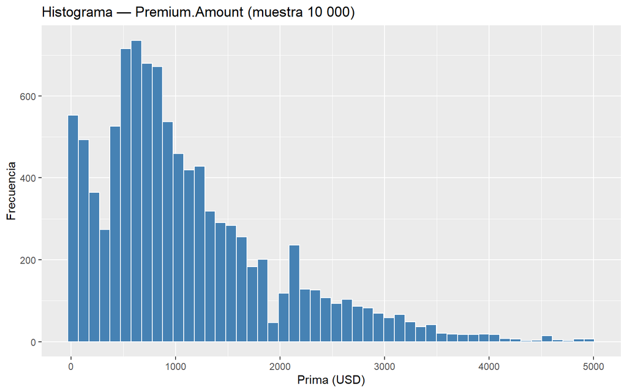

```r
set.seed(42)
df_muestra_norm <- df |> sample_n(min(10000, nrow(df)))

ggplot(df_muestra_norm, aes(x = Premium.Amount)) +
  geom_histogram(bins = 50, fill = "steelblue", color = "white") +
  labs(title = "Histograma — Premium.Amount (muestra 10 000)",
       x = "Prima (USD)", y = "Frecuencia")
```

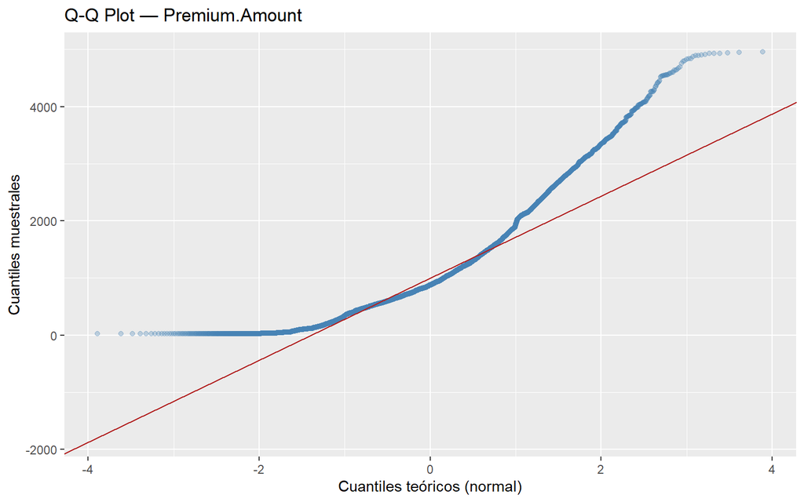

```r
ggplot(df_muestra_norm, aes(sample = Premium.Amount)) +
  geom_qq(alpha = 0.3, color = "steelblue") +
  geom_qq_line(color = "firebrick") +
  labs(title = "Q-Q Plot — Premium.Amount",
       x = "Cuantiles teóricos (normal)", y = "Cuantiles muestrales")
```

```r
# Lilliefors
lillie_premium <- nortest::lillie.test(df$Premium.Amount)
tabla_test(lillie_premium, "Prueba de Lilliefors — Premium.Amount")
```

Prueba de Lilliefors — Premium.Amount

| method | statistic | p.value |
| --- | --- | --- |
| Lilliefors (Kolmogorov-Smirnov) normality test | 0.1162 | 0 |

```r
# Normalidad de Premium.Amount por grupo de Smoking.Status (Lilliefors)
df_norm_grupos <- df |>
  group_by(Smoking.Status) |>
  summarise(n = n(), lf = list(nortest::lillie.test(Premium.Amount)), .groups = "drop") |>
  mutate(est_lillie = map_dbl(lf, ~ .x$statistic),
         p_lillie   = map_dbl(lf, ~ .x$p.value)) |>
  select(-lf)

knitr::kable(df_norm_grupos,
             digits = 4,
             caption = "Prueba de Lilliefors de normalidad por grupo de Smoking.Status",
             col.names = c("Grupo", "n", "D (Lilliefors)", "p (Lilliefors)"))
```

Prueba de Lilliefors de normalidad por grupo de Smoking.Status

| Grupo | n | D (Lilliefors) | p (Lilliefors) |
| --- | --- | --- | --- |
| No | 598127 | 0.1159 | 0 |
| Yes | 601873 | 0.1166 | 0 |

El histograma de la muestra conserva la asimetría positiva observada en el dataset completo. En el Q-Q plot, los puntos no siguen de manera estable la línea teórica, especialmente en las colas, lo que evidencia desviaciones de la normalidad. La prueba de Lilliefors es consistente con esta inspección visual (D = 0.1162, p = < 1e-04). El análisis por `Smoking.Status` muestra el mismo patrón. **Conclusión:** `Premium.Amount` no presenta un comportamiento aproximadamente normal, por lo que para las comparaciones grupales se prefieren pruebas no paramétricas.

**Nota metodológica:** con n = 1200000, cualquier prueba formal detectará incluso desviaciones triviales de la normalidad, produciendo p-valores prácticamente nulos. La decisión metodológica se fundamenta en la combinación del test formal con la inspección visual.

### 13.2 Homocedasticidad

Dado que `Premium.Amount` no sigue una distribución normal, se utiliza la prueba de Levene (Brown-Forsythe) para evaluar la igualdad de varianzas, ya que es robusta ante la falta de normalidad.

- **H₀:** las varianzas de los grupos son iguales.
- **H₁:** las varianzas difieren entre al menos dos grupos.
- **α = 0.05.**

```r
# Dos grupos: Smoking.Status
levene_smoke  <- car::leveneTest(Premium.Amount ~ Smoking.Status, data = df)
kt(as.data.frame(levene_smoke), caption = "Prueba de Levene — Smoking.Status")
```

Prueba de Levene — Smoking.Status

|  | Df | F value | Pr(>F) |
| --- | --- | --- | --- |
| group | 1 | 0.7404 | 0.3895 |
|  | 1199998 | NA | NA |

```r
# Tres grupos: Policy.Type
levene_policy <- car::leveneTest(Premium.Amount ~ Policy.Type, data = df)
kt(as.data.frame(levene_policy), caption = "Prueba de Levene — Policy.Type")
```

Prueba de Levene — Policy.Type

|  | Df | F value | Pr(>F) |
| --- | --- | --- | --- |
| group | 2 | 0.0703 | 0.9321 |
|  | 1199997 | NA | NA |

```r
p_levene_smoke  <- round(levene_smoke[1, "Pr(>F)"], 6)
p_levene_policy <- round(levene_policy[1, "Pr(>F)"], 6)
```

Para `Smoking.Status`, Levene obtuvo p = 0.389545; como p > 0.05, **no se rechaza H₀**, por lo que no hay evidencia de varianzas diferentes entre fumadores y no fumadores. Para `Policy.Type`, Levene obtuvo p = 0.932095; nuevamente p > 0.05, por lo que **no se rechaza H₀** y la homogeneidad de varianzas resulta razonable. La elección de Mann-Whitney y Kruskal-Wallis en las comparaciones posteriores se fundamenta principalmente en la falta de normalidad de `Premium.Amount`, no en una supuesta desigualdad de varianzas.

## 14 Correlaciones

Con base en la tabla de correlaciones exploratorias de la sección anterior, `Previous.Claims` y `Credit.Score` son las dos variables numéricas con mayor magnitud de correlación con `Premium.Amount`, por lo que se someten a un análisis formal de supuestos e inferencia. Dado que `Premium.Amount` no presenta normalidad (sección de Evaluación de supuestos), se utiliza la **correlación de Spearman** en lugar de Pearson.

### 14.1 Previous.Claims y Premium.Amount

Antes de aplicar Spearman se verifican los supuestos:

1. Escala ordinal o superior: `Previous.Claims` es un conteo discreto (0 a 9 reclamos previos, escala de razón) y `Premium.Amount` es continua (escala de razón); ambas pueden ordenarse.
2. Relación monótona: se comprueba mediante el diagrama de dispersión; a diferencia de Pearson, no se requiere que la relación sea lineal, solo que la tendencia sea consistente en una dirección.
3. Independencia: las observaciones corresponden a pólizas distintas; se asume independencia por la estructura del dataset.
4. Manejo de empates: al ser `Previous.Claims` discreta, genera numerosos empates; `cor.test()` con `method = "spearman"` los resuelve internamente asignando rangos promedio y usa la aproximación asintótica para el p-valor en presencia de empates.

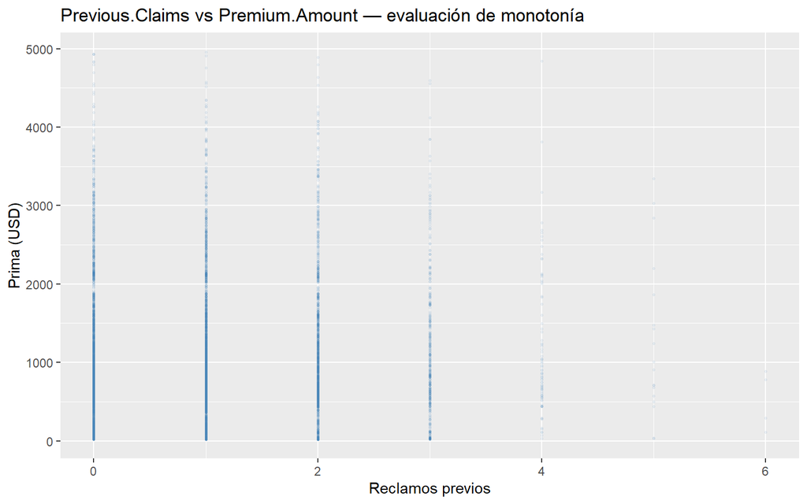

```r
ggplot(df_plot, aes(x = Previous.Claims, y = Premium.Amount)) +
  geom_point(alpha = 0.08, color = "steelblue", size = 0.5) +
  labs(title = "Previous.Claims vs Premium.Amount — evaluación de monotonía",
       x = "Reclamos previos", y = "Prima (USD)")
```

```r
cor_previous <- cor.test(df$Previous.Claims, df$Premium.Amount, method = "spearman")
tabla_test(cor_previous, "Correlación de Spearman — Previous.Claims vs Premium.Amount")
```

Correlación de Spearman — Previous.Claims vs Premium.Amount

| method | estimate | statistic | p.value | alternative |
| --- | --- | --- | --- | --- |
| Spearman’s rank correlation rho | 0.0356 | 2.777521e+17 | 0 | two.sided |

```r
rho_previous   <- cor_previous$estimate[[1]]
p_cor_previous <- cor_previous$p.value
n_previous     <- sum(complete.cases(df$Previous.Claims, df$Premium.Amount))

# IC 95% aproximado por transformacion z de Fisher (valido para n grande)
z_fisher    <- atanh(rho_previous)
se_fisher   <- sqrt((1 + rho_previous^2 / 2) / (n_previous - 3))  # Bonett y Wright (2000)
ic_previous <- round(tanh(z_fisher + c(-1, 1) * qnorm(0.975) * se_fisher), 4)

r_previous   <- round(rho_previous, 4)
magnitud_h3  <- ifelse(abs(r_previous) < 0.10, "insignificante",
                ifelse(abs(r_previous) < 0.30, "débil",
                ifelse(abs(r_previous) < 0.50, "moderada",
                ifelse(abs(r_previous) < 0.70, "moderada-fuerte", "fuerte"))))
direccion_h3 <- ifelse(r_previous > 0, "positiva", "negativa")
decision_h3 <- ifelse(
  p_cor_previous < 0.05,
  "Se rechaza H₀. Existe evidencia estadística de una correlación monótona distinta de cero entre Previous.Claims y Premium.Amount; sin embargo, su magnitud es prácticamente nula.",
  "No se rechaza H₀. No existe evidencia estadística suficiente de una correlación monótona distinta de cero entre Previous.Claims y Premium.Amount."
)
```

Al ser `Previous.Claims` una variable discreta, el diagrama de dispersión muestra bandas verticales en vez de una nube continua; dentro de cada banda la dispersión de `Premium.Amount` es amplia y no se observa una tendencia monótona clara del promedio de la prima a medida que aumenta el número de reclamos previos. La escala de ambas variables y la independencia de las observaciones permiten aplicar Spearman; la naturaleza discreta de `Previous.Claims` implica numerosos empates, que la prueba resuelve mediante rangos promedio.

La correlación de Spearman entre `Previous.Claims` y `Premium.Amount` es ρ = 0.0356 (IC 95% aproximado por transformación z de Fisher con el error estándar de Bonett y Wright para Spearman: [0.0338, 0.0374], p = < 1e-04), lo que indica una asociación **insignificante** y **positiva**. Aunque el p-valor es pequeño, la magnitud de ρ es prácticamente nula; por tanto, la significancia estadística no implica una relación monótona relevante en términos prácticos.

### 14.2 Credit.Score y Premium.Amount

Se aplica el mismo proceso de verificación de supuestos de Spearman: escala ordinal o superior, relación monótona, independencia de observaciones y manejo de empates.

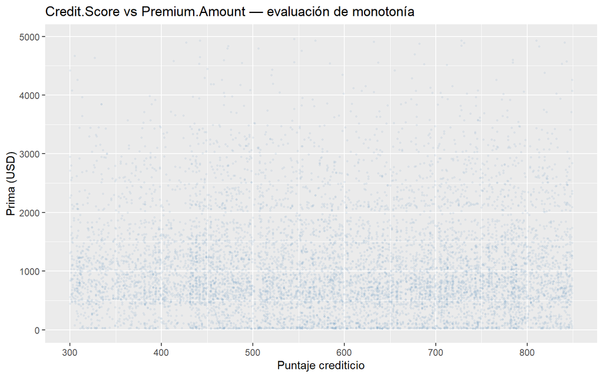

```r
ggplot(df_plot, aes(x = Credit.Score, y = Premium.Amount)) +
  geom_point(alpha = 0.08, color = "steelblue", size = 0.5) +
  labs(title = "Credit.Score vs Premium.Amount — evaluación de monotonía",
       x = "Puntaje crediticio", y = "Prima (USD)")
```

```r
cor_credit <- cor.test(df$Credit.Score, df$Premium.Amount, method = "spearman")
tabla_test(cor_credit, "Correlación de Spearman — Credit.Score vs Premium.Amount")
```

Correlación de Spearman — Credit.Score vs Premium.Amount

| method | estimate | statistic | p.value | alternative |
| --- | --- | --- | --- | --- |
| Spearman’s rank correlation rho | -0.0413 | 2.998869e+17 | 0 | two.sided |

```r
rho_credit   <- cor_credit$estimate[[1]]
p_cor_credit <- cor_credit$p.value
n_credit     <- sum(complete.cases(df$Credit.Score, df$Premium.Amount))

# IC 95% aproximado por transformacion z de Fisher (valido para n grande)
z_fisher_credit  <- atanh(rho_credit)
se_fisher_credit <- sqrt((1 + rho_credit^2 / 2) / (n_credit - 3))  # Bonett y Wright (2000)
ic_credit        <- round(tanh(z_fisher_credit + c(-1, 1) * qnorm(0.975) * se_fisher_credit), 4)

r_credit    <- round(rho_credit, 4)
magnitud_h4 <- ifelse(abs(r_credit) < 0.10, "insignificante",
               ifelse(abs(r_credit) < 0.30, "débil",
               ifelse(abs(r_credit) < 0.50, "moderada",
               ifelse(abs(r_credit) < 0.70, "moderada-fuerte", "fuerte"))))
direccion_h4 <- ifelse(r_credit > 0, "positiva", "negativa")
decision_h4 <- ifelse(
  p_cor_credit < 0.05,
  "Se rechaza H₀. Existe evidencia estadística de una correlación monótona distinta de cero entre Credit.Score y Premium.Amount; sin embargo, su magnitud es prácticamente nula.",
  "No se rechaza H₀. No existe evidencia estadística suficiente de una correlación monótona distinta de cero entre Credit.Score y Premium.Amount."
)
```

La nube de puntos de `Credit.Score` frente a `Premium.Amount` no muestra una tendencia monótona visualmente clara frente a la amplia dispersión de la prima. Ambas variables cumplen escala de razón y la independencia de las observaciones se justifica por la estructura del dataset, por lo que es razonable aplicar Spearman como medida de asociación monótona.

La correlación de Spearman entre `Credit.Score` y `Premium.Amount` es ρ = -0.0413 (IC 95% aproximado por transformación z de Fisher con el error estándar de Bonett y Wright para Spearman: [-0.0431, -0.0395], p = < 1e-04), indicando una asociación **insignificante** y **negativa**. El rechazo de H₀ se explica por el gran tamaño muestral, pero la magnitud observada es prácticamente nula y no representa una relación monótona de importancia práctica.

### 14.3 Sensibilidad a la imputación

Como `Previous.Claims` y `Credit.Score` tienen una proporción alta de valores imputados, se recalcula la correlación de Spearman solo con los casos completos del dataset original, sin imputar.

```r
sens_imp <- map_dfr(c("Previous.Claims", "Credit.Score"), function(v) {
  ok <- complete.cases(train[[v]], train$Premium.Amount)
  ct <- cor.test(train[[v]][ok], train$Premium.Amount[ok], method = "spearman", exact = FALSE)
  tibble(Variable = v,
         `n casos completos` = sum(ok),
         `ρ casos completos` = unname(ct$estimate),
         `p (casos completos)` = ct$p.value,
         `ρ con imputación` = if (v == "Previous.Claims") rho_previous else rho_credit)
})
kt(sens_imp, caption = "Spearman con casos completos frente a datos imputados")
```

Spearman con casos completos frente a datos imputados

| Variable | n casos completos | ρ casos completos | p (casos completos) | ρ con imputación |
| --- | --- | --- | --- | --- |
| Previous.Claims | 835971 | 0.0445 | 0 | 0.0356 |
| Credit.Score | 1062118 | -0.0439 | 0 | -0.0413 |

Con casos completos, ρ = 0.0445 para `Previous.Claims` y ρ = -0.0439 para `Credit.Score`, frente a 0.0356 y -0.0413 con imputación. La imputación atenúa ligeramente las correlaciones, como se anticipó, pero en ambos casos la magnitud sigue siendo insignificante y las conclusiones de H3 y H4 no cambian.

## 15 Pruebas de hipótesis

Para cada prueba se especifican las hipótesis, se comprueban los supuestos, se ejecuta la prueba y se interpreta la decisión junto con el tamaño del efecto.

### 15.1 H1 — ¿Existen diferencias en la prima de seguro entre fumadores y no fumadores?

**Hipótesis**

- H₀: La distribución de la prima de seguro es igual en fumadores y no fumadores.
- H₁: La distribución de la prima de seguro difiere entre fumadores y no fumadores.

**Nivel de significancia:** α = 0.05.

**Comprobación de supuestos:** la normalidad fue rechazada en ambos grupos (sección anterior). Levene obtuvo p = 0.389545, por lo que no hay evidencia de varianzas diferentes. Debido principalmente a la falta de normalidad, se emplea la **prueba de Mann-Whitney U** (Wilcoxon de dos muestras independientes).

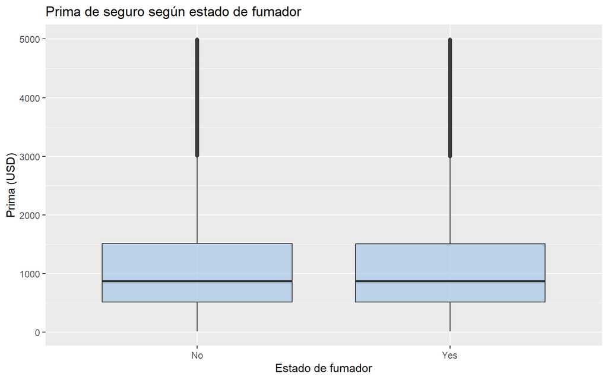

```r
ggplot(df, aes(x = Smoking.Status, y = Premium.Amount)) +
  geom_boxplot(fill = "#A7C7E7", alpha = 0.7, outlier.alpha = 0.05) +
  labs(title = "Prima de seguro según estado de fumador",
       x = "Estado de fumador", y = "Prima (USD)")
```

```r
wilcox_smoke <- wilcox.test(Premium.Amount ~ Smoking.Status, data = df)
tabla_test(wilcox_smoke, "Prueba de Mann-Whitney U — Smoking.Status")
```

Prueba de Mann-Whitney U — Smoking.Status

| method | statistic | p.value | alternative |
| --- | --- | --- | --- |
| Wilcoxon rank sum test with continuity correction | 179920076580 | 0.6803 | two.sided |

```r
effsize_smoke <- rstatix::wilcox_effsize(df, Premium.Amount ~ Smoking.Status)
kt(effsize_smoke, caption = "Tamaño del efecto r (Wilcoxon)")
```

Tamaño del efecto r (Wilcoxon)

| .y. | group1 | group2 | effsize | n1 | n2 | magnitude |
| --- | --- | --- | --- | --- | --- | --- |
| Premium.Amount | No | Yes | 4e-04 | 598127 | 601873 | small |

```r
p_h1                 <- wilcox_smoke$p.value
r_smoke_val          <- round(effsize_smoke$effsize, 4)
r_smoke_magn         <- as.character(effsize_smoke$magnitude)
smoke_yes            <- df$Premium.Amount[df$Smoking.Status == "Yes"]
smoke_no             <- df$Premium.Amount[df$Smoking.Status == "No"]
mediana_fumadores    <- round(median(smoke_yes), 2)
mediana_no_fumadores <- round(median(smoke_no),  2)
media_fumadores      <- round(mean(smoke_yes), 2)
media_no_fumadores   <- round(mean(smoke_no),  2)
w_h1_fmt              <- format(round(as.numeric(wilcox_smoke$statistic), 0),
                                big.mark = ",", scientific = FALSE, trim = TRUE)
p_h1_fmt              <- format.pval(p_h1, digits = 4, eps = 1e-4)
r_smoke_fmt           <- formatC(r_smoke_val, format = "f", digits = 4)
decision_h1 <- ifelse(
  p_h1 < 0.05,
  "Se rechaza H₀. Existe evidencia estadística de diferencias en la distribución de la prima entre fumadores y no fumadores.",
  "No se rechaza H₀. No existe evidencia estadística suficiente para afirmar que la distribución de la prima difiere entre fumadores y no fumadores."
)
```

Las cajas de fumadores y no fumadores presentan un alto grado de solapamiento y la mediana es 872 USD en fumadores y 872 USD en no fumadores. La similitud visual entre las distribuciones anticipa una diferencia pequeña o inexistente.

**Resultado:** W = 179,920,076,580, p = 0.6803. La media es 1102.69 USD en fumadores y 1102.4 USD en no fumadores. El tamaño del efecto de Wilcoxon es r = 0.0004, clasificado por la función como **small**; numéricamente se encuentra muy próximo a cero.

**Decisión:** No se rechaza H₀. No existe evidencia estadística suficiente para afirmar que la distribución de la prima difiere entre fumadores y no fumadores.